# **Problem Statement**

## Business Context

A sales forecast is a prediction of future sales revenue based on historical data, industry trends, and the status of the current sales pipeline. Businesses use the sales forecast to estimate weekly, monthly, quarterly, and annual sales totals. A company needs to make an accurate sales forecast as it adds value across an organization and helps the different verticals to chalk out their future course of action.

Forecasting helps an organization plan its sales operations by region and provides valuable insights to the supply chain team regarding the procurement of goods and materials. An accurate sales forecast process has many benefits which include improved decision-making about the future and reduction of sales pipeline and forecast risks. Moreover, it helps to reduce the time spent in planning territory coverage and establish benchmarks that can be used to assess trends in the future.

## Objective

SuperKart is a retail chain operating supermarkets and food marts across various tier cities, offering a wide range of products. To optimize its inventory management and make informed decisions around regional sales strategies, SuperKart wants to accurately forecast the sales revenue of its outlets for the upcoming quarter.

To operationalize these insights at scale, the company has partnered with a data science firm—not just to build a predictive model based on historical sales data, but to develop and deploy a robust forecasting solution that can be integrated into SuperKart’s decision-making systems and used across its network of stores.

## Data Description

The data contains the different attributes of the various products and stores.The detailed data dictionary is given below.

- **Product_Id** - unique identifier of each product, each identifier having two letters at the beginning followed by a number.
- **Product_Weight** - weight of each product
- **Product_Sugar_Content** - sugar content of each product like low sugar, regular and no sugar
- **Product_Allocated_Area** - ratio of the allocated display area of each product to the total display area of all the products in a store
- **Product_Type** - broad category for each product like meat, snack foods, hard drinks, dairy, canned, soft drinks, health and hygiene, baking goods, bread, breakfast, frozen foods, fruits and vegetables, household, seafood, starchy foods, others
- **Product_MRP** - maximum retail price of each product
- **Store_Id** - unique identifier of each store
- **Store_Establishment_Year** - year in which the store was established
- **Store_Size** - size of the store depending on sq. feet like high, medium and low
- **Store_Location_City_Type** - type of city in which the store is located like Tier 1, Tier 2 and Tier 3. Tier 1 consists of cities where the standard of living is comparatively higher than its Tier 2 and Tier 3 counterparts.
- **Store_Type** - type of store depending on the products that are being sold there like Departmental Store, Supermarket Type 1, Supermarket Type 2 and Food Mart
- **Product_Store_Sales_Total** - total revenue generated by the sale of that particular product in that particular store

# **Installing and Importing the necessary libraries**

```python
#Installing the libraries with the specified versions
#!pip install numpy==2.0.2 pandas==2.2.2 scikit-learn==1.6.1 matplotlib==3.10.0 seaborn==0.13.2 joblib==1.4.2 xgboost==2.1.4 requests==2.32.3 huggingface_hub==0.30.1 -q
!pip install numpy pandas scikit-learn matplotlib seaborn joblib xgboost requests huggingface_hub -q
```

**Note:**

- After running the above cell, kindly restart the notebook kernel (for Jupyter Notebook) or runtime (for Google Colab) and run all cells sequentially from the next cell.
- On executing the above line of code, you might see a warning regarding package dependencies. This error message can be ignored as the above code ensures that all necessary libraries and their dependencies are maintained to successfully execute the code in this notebook.

```python
import warnings
warnings.filterwarnings("ignore")

# Libraries to help with reading and manipulating data
import numpy as np
import pandas as pd
from typing import Tuple, Dict

# For splitting the dataset
from sklearn.model_selection import train_test_split, RandomizedSearchCV, KFold, cross_val_score

# Libaries to help with data visualization
import matplotlib.pyplot as plt
import seaborn as sns

# Removes the limit for the number of displayed columns
pd.set_option("display.max_columns", None)
# Sets the limit for the number of displayed rows
pd.set_option("display.max_rows", 100)


# Libraries different ensemble classifiers
from sklearn.ensemble import (
    BaggingRegressor,
    RandomForestRegressor,
    AdaBoostRegressor,
    GradientBoostingRegressor,
)
from xgboost import XGBRegressor
from sklearn.tree import DecisionTreeRegressor
from sklearn.impute import SimpleImputer
import xgboost as xgb

# Libraries to get different metric scores
from sklearn.metrics import (
    confusion_matrix,
    accuracy_score,
    precision_score,
    recall_score,
    f1_score,
    mean_squared_error,
    mean_absolute_error,
    r2_score,
    mean_absolute_percentage_error
)

# To create the pipeline
from sklearn.compose import make_column_transformer, ColumnTransformer
from sklearn.pipeline import make_pipeline,Pipeline

# To tune different models and standardize
from sklearn.model_selection import GridSearchCV
from sklearn.preprocessing import StandardScaler,OneHotEncoder

# To serialize the model
import joblib

# os related functionalities
import os

# API request
import requests

# For hyperparameter tuning
import itertools

# for hugging face space authentication to upload files
from huggingface_hub import login, HfApi
```

# **Loading the dataset**

```python
# Loading the dataset
dataset=pd.read_csv("SuperKart.csv")
```

```python
# Making a copy of the original dataset
data=dataset.copy()
```

# **Data Overview**

### View the first 5 and last 5 rows of the dataset

```python
### View the first 5 rows
data.head()
```

|  | Product_Id | Product_Weight | Product_Sugar_Content | Product_Allocated_Area | Product_Type | Product_MRP | Store_Id | Store_Establishment_Year | Store_Size | Store_Location_City_Type | Store_Type | Product_Store_Sales_Total |
| --- | --- | --- | --- | --- | --- | --- | --- | --- | --- | --- | --- | --- |
| 0 | FD6114 | 12.66 | Low Sugar | 0.027 | Frozen Foods | 117.08 | OUT004 | 2009 | Medium | Tier 2 | Supermarket Type2 | 2842.40 |
| 1 | FD7839 | 16.54 | Low Sugar | 0.144 | Dairy | 171.43 | OUT003 | 1999 | Medium | Tier 1 | Departmental Store | 4830.02 |
| 2 | FD5075 | 14.28 | Regular | 0.031 | Canned | 162.08 | OUT001 | 1987 | High | Tier 2 | Supermarket Type1 | 4130.16 |
| 3 | FD8233 | 12.10 | Low Sugar | 0.112 | Baking Goods | 186.31 | OUT001 | 1987 | High | Tier 2 | Supermarket Type1 | 4132.18 |
| 4 | NC1180 | 9.57 | No Sugar | 0.010 | Health and Hygiene | 123.67 | OUT002 | 1998 | Small | Tier 3 | Food Mart | 2279.36 |

```python
# view the last 5 rows
data.tail()
```

|  | Product_Id | Product_Weight | Product_Sugar_Content | Product_Allocated_Area | Product_Type | Product_MRP | Store_Id | Store_Establishment_Year | Store_Size | Store_Location_City_Type | Store_Type | Product_Store_Sales_Total |
| --- | --- | --- | --- | --- | --- | --- | --- | --- | --- | --- | --- | --- |
| 8758 | NC7546 | 14.80 | No Sugar | 0.016 | Health and Hygiene | 140.53 | OUT004 | 2009 | Medium | Tier 2 | Supermarket Type2 | 3806.53 |
| 8759 | NC584 | 14.06 | No Sugar | 0.142 | Household | 144.51 | OUT004 | 2009 | Medium | Tier 2 | Supermarket Type2 | 5020.74 |
| 8760 | NC2471 | 13.48 | No Sugar | 0.017 | Health and Hygiene | 88.58 | OUT001 | 1987 | High | Tier 2 | Supermarket Type1 | 2443.42 |
| 8761 | NC7187 | 13.89 | No Sugar | 0.193 | Household | 168.44 | OUT001 | 1987 | High | Tier 2 | Supermarket Type1 | 4171.82 |
| 8762 | FD306 | 14.73 | Low Sugar | 0.177 | Snack Foods | 224.93 | OUT002 | 1998 | Small | Tier 3 | Food Mart | 2186.08 |

### Checking the shape of the dataset

```python
# Checking the shape of the dataset
print(f"There are {data.shape[0]} rows and {data.shape[1]} columns.")
```

```
There are 8763 rows and 12 columns.
```

### Checking the data types and non-null values

```python
# Checking the data types and non-null values
data.info()
```

```
<class 'pandas.core.frame.DataFrame'>
RangeIndex: 8763 entries, 0 to 8762
Data columns (total 12 columns):
 #   Column                     Non-Null Count  Dtype
---  ------                     --------------  -----
 0   Product_Id                 8763 non-null   object
 1   Product_Weight             8763 non-null   float64
 2   Product_Sugar_Content      8763 non-null   object
 3   Product_Allocated_Area     8763 non-null   float64
 4   Product_Type               8763 non-null   object
 5   Product_MRP                8763 non-null   float64
 6   Store_Id                   8763 non-null   object
 7   Store_Establishment_Year   8763 non-null   int64
 8   Store_Size                 8763 non-null   object
 9   Store_Location_City_Type   8763 non-null   object
 10  Store_Type                 8763 non-null   object
 11  Product_Store_Sales_Total  8763 non-null   float64
dtypes: float64(4), int64(1), object(7)
memory usage: 821.7+ KB
```

### Getting a statistical summary of the dataset

```python
# Getting a statistical summary of the dataset
data.describe(include="all").T
```

|  | count | unique | top | freq | mean | std | min | 25% | 50% | 75% | max |
| --- | --- | --- | --- | --- | --- | --- | --- | --- | --- | --- | --- |
| Product_Id | 8763 | 8763 | FD6114 | 1 | NaN | NaN | NaN | NaN | NaN | NaN | NaN |
| Product_Weight | 8763.0 | NaN | NaN | NaN | 12.653792 | 2.21732 | 4.0 | 11.15 | 12.66 | 14.18 | 22.0 |
| Product_Sugar_Content | 8763 | 4 | Low Sugar | 4885 | NaN | NaN | NaN | NaN | NaN | NaN | NaN |
| Product_Allocated_Area | 8763.0 | NaN | NaN | NaN | 0.068786 | 0.048204 | 0.004 | 0.031 | 0.056 | 0.096 | 0.298 |
| Product_Type | 8763 | 16 | Fruits and Vegetables | 1249 | NaN | NaN | NaN | NaN | NaN | NaN | NaN |
| Product_MRP | 8763.0 | NaN | NaN | NaN | 147.032539 | 30.69411 | 31.0 | 126.16 | 146.74 | 167.585 | 266.0 |
| Store_Id | 8763 | 4 | OUT004 | 4676 | NaN | NaN | NaN | NaN | NaN | NaN | NaN |
| Store_Establishment_Year | 8763.0 | NaN | NaN | NaN | 2002.032751 | 8.388381 | 1987.0 | 1998.0 | 2009.0 | 2009.0 | 2009.0 |
| Store_Size | 8763 | 3 | Medium | 6025 | NaN | NaN | NaN | NaN | NaN | NaN | NaN |
| Store_Location_City_Type | 8763 | 3 | Tier 2 | 6262 | NaN | NaN | NaN | NaN | NaN | NaN | NaN |
| Store_Type | 8763 | 4 | Supermarket Type2 | 4676 | NaN | NaN | NaN | NaN | NaN | NaN | NaN |
| Product_Store_Sales_Total | 8763.0 | NaN | NaN | NaN | 3464.00364 | 1065.630494 | 33.0 | 2761.715 | 3452.34 | 4145.165 | 8000.0 |

```python
# Checking for missing values
data.duplicated().sum()
```

```
np.int64(0)
```

### Checking for missing values

```python
# Checking for missing values
data.isnull().sum()
```

```
Product_Id                   0
Product_Weight               0
Product_Sugar_Content        0
Product_Allocated_Area       0
Product_Type                 0
Product_MRP                  0
Store_Id                     0
Store_Establishment_Year     0
Store_Size                   0
Store_Location_City_Type     0
Store_Type                   0
Product_Store_Sales_Total    0
dtype: int64
```

## 🧭 Data Overview — Observations and Insights

### General Structure

- The dataset contains **8,763 rows and 12 columns**, representing individual product–store combinations.
- Each row corresponds to the total sales (`Product_Store_Sales_Total`) for a specific product (`Product_Id`) within a particular store (`Store_Id`).

### Data Completeness

- There are **no missing values** across any columns, which means the dataset is **clean and complete** for modeling.
- There are **no duplicate records**, indicating unique product–store pairs.
- This provides a strong foundation for data analysis without the need for imputation or deduplication steps.

### Data Types

- **7 categorical variables** (`object` type): Product identifiers, sugar content, product type, store ID, store size, city tier, and store type.
- **4 numerical variables** (`float64` or `int64`): Product weight, allocated area, MRP (price), and establishment year.
- The target variable `Product_Store_Sales_Total` is also numeric (`float64`).

### Numerical Summary

- **Product_Weight** ranges from **4.0 to 22.0**, suggesting a variety of product sizes.
- **Product_Allocated_Area** values are between **0.004 and 0.298**, showing different shelf space allocations across products.
- **Product_MRP** (Maximum Retail Price) varies widely, from **31.0 to 266.0**, implying a mix of low- and high-value items.
- The **average total sales** per product–store (`Product_Store_Sales_Total`) is approximately **3,464 units**, with a standard deviation of around **1,065**, showing moderate variability in sales performance.

### Categorical Insights

- There are **16 distinct product categories**, with **“Fruits and Vegetables”** being the most common (1,249 entries).
- **Store_Size** has three levels: `Small`, `Medium`, and `High`, with `Medium` being the most frequent (~6,000 records).
- **Store_Location_City_Type** includes `Tier 1`, `Tier 2`, and `Tier 3`, dominated by `Tier 2` cities (~6,200 records), which likely represent mid-sized urban markets.
- **Store_Type** includes four categories, where `Supermarket Type2` appears most often (4,676 entries).

### Key Takeaways

- The dataset is **high quality** with **no missing or duplicated data**.
- Both **product- and store-level diversity** exist — ideal for building a forecasting model that generalizes across multiple categories and store types.
- The presence of **categorical attributes** (e.g., `Store_Size`, `Product_Type`) alongside **numerical predictors** (e.g., `MRP`, `Allocated_Area`) suggests that a **mixed preprocessing pipeline** (encoding + scaling) will be essential.
- The broad range of sales values and product characteristics implies **non-linear relationships**, which aligns well with tree-based regression models such as **Random Forest** and **Gradient Boosting** for the next modeling phase.

# **Exploratory Data Analysis (EDA)**

## Univariate Analysis

```python
# Function to plot combined histogram and boxplot for a numerical feature

def histogram_boxplot(
    data, feature, figsize=(12, 7), kde=True, bins=30,
    color="royalblue", title=None, show_mean=True, show_median=True, grid=True
):
    """
    Combined boxplot and histogram for a numerical feature.

    Parameters
    ----------
    data : pandas.DataFrame
        Dataset containing the feature to visualize.
    feature : str
        Column name of the numerical feature to plot.
    figsize : tuple, optional
        Figure size, default is (12, 7).
    kde : bool, optional
        Whether to show a Kernel Density Estimate on the histogram. Default is True.
    bins : int, optional
        Number of histogram bins. Default is 30.
    color : str, optional
        Base color for plots. Default is 'royalblue'.
    title : str, optional
        Title for the combined plot. If None, uses the feature name.
    show_mean : bool, optional
        Whether to display a vertical line for the mean. Default is True.
    show_median : bool, optional
        Whether to display a vertical line for the median. Default is True.
    grid : bool, optional
        Whether to show grid lines on the histogram. Default is True.

    Returns
    -------
    matplotlib.figure.Figure
        The generated Matplotlib figure.
    """

    # Create subplots: boxplot on top, histogram below
    fig, (ax_box, ax_hist) = plt.subplots(
        nrows=2,
        sharex=True,
        gridspec_kw={"height_ratios": (0.25, 0.75)},
        figsize=figsize
    )

    # --- Boxplot ---
    sns.boxplot(
        data=data,
        x=feature,
        ax=ax_box,
        color=sns.color_palette("coolwarm", 8)[2],
        showmeans=True,
        meanprops={"marker": "o", "markerfacecolor": "white", "markeredgecolor": "black"}
    )
    ax_box.set(xlabel=None)
    ax_box.set_title(
        title if title else f"Distribution of {feature}",
        fontsize=14,
        fontweight="bold"
    )

    # --- Histogram ---
    sns.histplot(
        data=data,
        x=feature,
        bins=bins,
        kde=kde,
        ax=ax_hist,
        color=color,
        edgecolor="black",
        alpha=0.75
    )

    # Add mean and median lines
    mean_val = data[feature].mean()
    median_val = data[feature].median()
    if show_mean:
        ax_hist.axvline(mean_val, color="red", linestyle="--", linewidth=1.5, label=f"Mean: {mean_val:.2f}")
    if show_median:
        ax_hist.axvline(median_val, color="black", linestyle="-", linewidth=1.2, label=f"Median: {median_val:.2f}")

    # Final touches
    if grid:
        ax_hist.grid(alpha=0.3)
    ax_hist.legend()
    plt.tight_layout()

    return fig
```

## 🔹 Univariate Analysis — Numerical Variables

In this section, we will explore the distribution of all numerical variables in the dataset. The following plots combine **histograms** and **boxplots** to identify:

- The spread of the data
- The presence of outliers
- The symmetry or skewness of each distribution
- Any differences in central tendency (mean vs. median)

```python
# Identify numerical features (excluding the target if desired)
numeric_features = data.select_dtypes(include=["int64", "float64"]).columns.tolist()

print("Numeric features:", numeric_features)
```

```
Numeric features: ['Product_Weight', 'Product_Allocated_Area', 'Product_MRP', 'Store_Establishment_Year', 'Product_Store_Sales_Total']
```

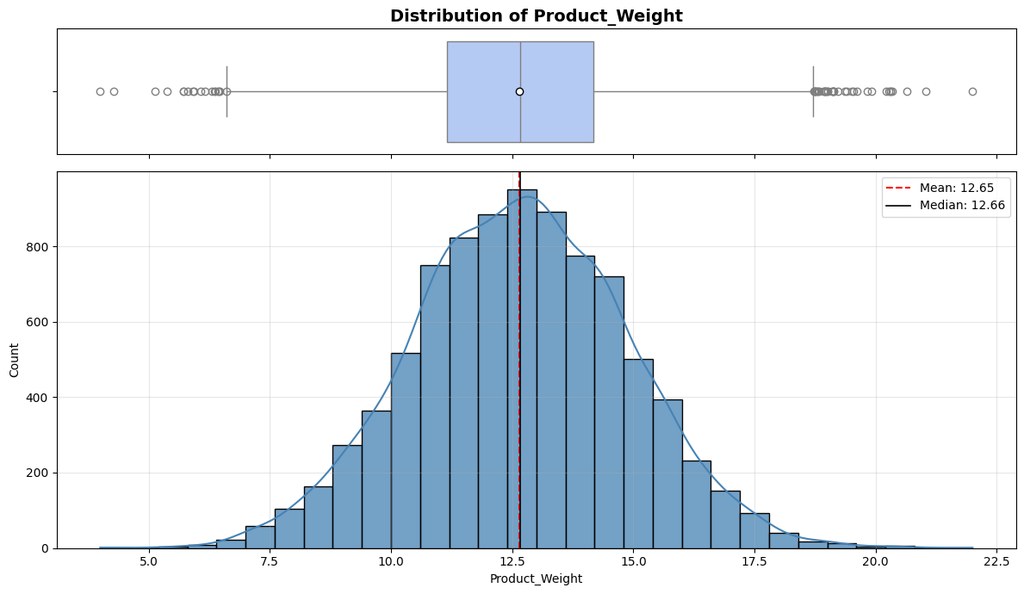

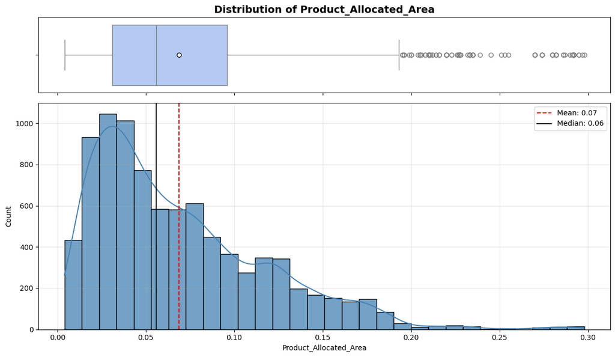

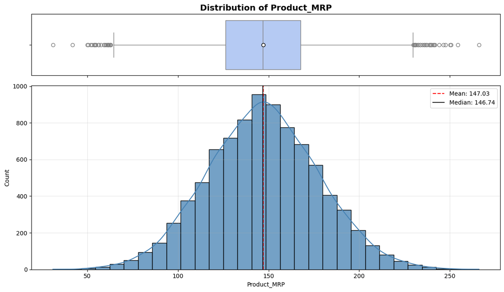

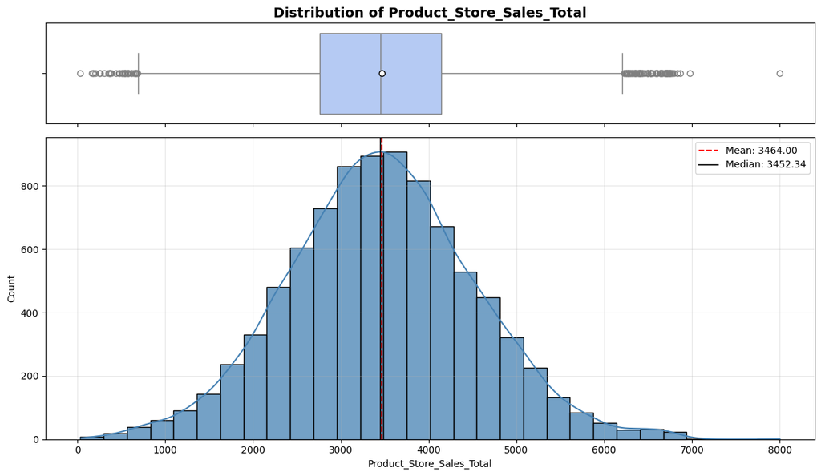

```python
# Plot distributions for all numeric variables
for col in numeric_features:
    if col != "Store_Establishment_Year":  # exclude Store_Establishment_Year
        histogram_boxplot(data, col, kde=True, bins=30, color="steelblue")
```

## 🔹 Univariate Analysis — Categorical Variables

In this section, we analyze the categorical features in the dataset.  
The labeled bar plots below show the **frequency distribution** (or percentages) of each category.  
These charts help us identify:

- Which categories dominate each feature
- Whether the data is balanced or skewed
- Potential grouping opportunities (e.g., low-frequency categories to combine)

```python
# Function to create a labeled bar plot for categorical features

def labeled_barplot(
    data: pd.DataFrame,
    feature: str,
    top: int | None = None,          # Show only top N categories
    perc: bool = False,              # Display percentages instead of counts
    sort: str = "desc",              # Sorting order: 'desc', 'asc', or 'alpha'
    orient: str = "v",               # Orientation: 'v' (vertical) or 'h' (horizontal)
    color: str | None = None,        # Single color for bars
    palette: str = "Paired",         # Palette if no single color is set
    min_pct: float | None = None,    # Group categories below this percentage as 'Other' (e.g. 0.01)
    dropna: bool = True,             # Exclude NaN values
    title: str | None = None,        # Custom title for the plot
    figsize: tuple | None = None,    # Automatically adjusts if not provided
    value_fmt: str | None = None,    # Format for values (e.g. "{:,}" for comma separators)
    font_size: int = 11              # Font size for the bar labels
):
    """
    Create a labeled bar plot with optional percentage annotations and category filtering.

    Parameters
    ----------
    data : pandas.DataFrame
        The input dataset containing the feature.
    feature : str
        The categorical column name to visualize.
    top : int, optional
        Display only the top N categories. If None, show all.
    perc : bool, optional
        Display percentages instead of absolute counts. Default is False.
    sort : str, optional
        Sort order: 'desc' (default), 'asc', or 'alpha' (alphabetical).
    orient : str, optional
        Orientation of bars: 'v' for vertical or 'h' for horizontal.
    color : str, optional
        Fixed color for all bars. If None, uses the palette argument.
    palette : str, optional
        Seaborn color palette when color is not provided.
    min_pct : float, optional
        Combine categories below this fraction of total into 'Other'. Example: 0.02 groups <2%.
    dropna : bool, optional
        Whether to exclude NaN values from the plot. Default is True.
    title : str, optional
        Title for the plot. If None, a default descriptive title is created.
    figsize : tuple, optional
        Custom figure size. If None, automatically adjusted based on number of categories.
    value_fmt : str, optional
        Format string for numerical labels. Example: "{:,}" to show thousands separators.
    font_size : int, optional
        Font size for the numeric labels above/beside bars.

    Returns
    -------
    fig, ax : tuple
        Matplotlib Figure and Axes objects for further customization.
    """

    # --- Prepare the series for plotting ---
    s = data[feature].dropna() if dropna else data[feature]
    total = len(s)

    # Group rare categories as "Other"
    if min_pct is not None and min_pct > 0:
        freqs = s.value_counts(normalize=True)
        rare = freqs[freqs < min_pct].index
        s = s.mask(s.isin(rare), "Other")

    # Compute category counts
    counts = s.value_counts(dropna=not dropna)

    # Keep only the top-N categories
    if top is not None and top > 0:
        counts = counts.head(top)

    # Apply sorting
    if sort == "asc":
        counts = counts.sort_values(ascending=True)
    elif sort == "alpha":
        counts = counts.sort_index()
    else:  # Default: descending
        counts = counts.sort_values(ascending=False)

    cats = counts.index.tolist()
    vals = counts.values
    n_cats = len(cats)

    # Dynamically determine figure size if not provided
    if figsize is None:
        if orient == "v":
            figsize = (max(6, min(0.6 * n_cats + 2, 18)), 5.5)
        else:
            figsize = (8.5, max(5, min(0.4 * n_cats + 2, 16)))

    fig, ax = plt.subplots(figsize=figsize)

    # Choose color or palette
    bar_kwargs = {"color": color} if color else {"palette": palette}

    # Create the bar plot
    if orient == "v":
        sns.barplot(x=cats, y=vals, ax=ax, **bar_kwargs)
        ax.set_xlabel(feature)
        ax.set_ylabel("Percentage" if perc else "Count")
        ax.tick_params(axis="x", rotation=45)
    else:
        sns.barplot(x=vals, y=cats, ax=ax, **bar_kwargs)
        ax.set_ylabel(feature)
        ax.set_xlabel("Percentage" if perc else "Count")

    # Annotate each bar with value or percentage
    for p in ax.patches:
        val = p.get_height() if orient == "v" else p.get_width()
        label = f"{val/total:.1%}" if perc else (value_fmt.format(val) if value_fmt else f"{int(val):,}")

        if orient == "v":
            ax.annotate(
                label,
                (p.get_x() + p.get_width() / 2, val),
                ha="center", va="bottom",
                xytext=(0, 3), textcoords="offset points",
                fontsize=font_size
            )
        else:
            ax.annotate(
                label,
                (val, p.get_y() + p.get_height() / 2),
                ha="left", va="center",
                xytext=(3, 0), textcoords="offset points",
                fontsize=font_size
            )

    # Set the plot title
    if title is None:
        title = f"{feature} — Top {top}" if top else f"{feature} — Distribution"
        if min_pct:
            title += f" (rare < {min_pct:.0%} → 'Other')"
    ax.set_title(title, fontsize=13, fontweight="bold")

    sns.despine()
    plt.tight_layout()
    return fig, ax
```

```python
# Identify categorical variables in the dataset
categorical_features = data.select_dtypes(include=["object"]).columns.tolist()

print("Categorical features:")
for col in categorical_features:
    print(f" - {col}")
```

```
Categorical features:
 - Product_Id
 - Product_Sugar_Content
 - Product_Type
 - Store_Id
 - Store_Size
 - Store_Location_City_Type
 - Store_Type
```

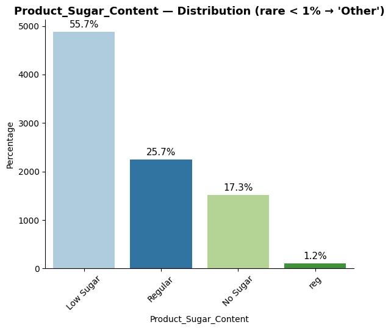

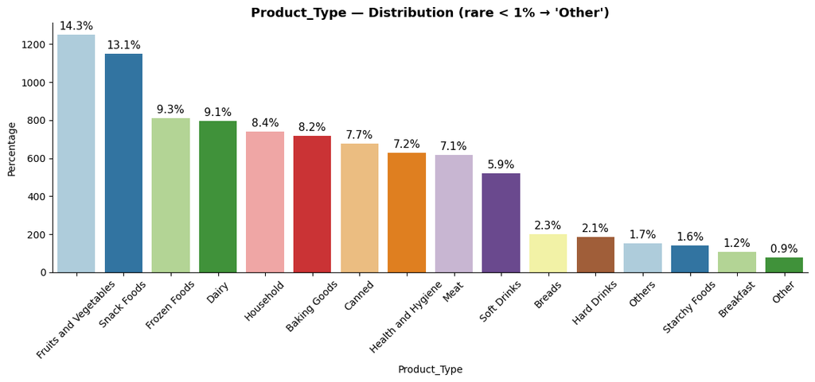

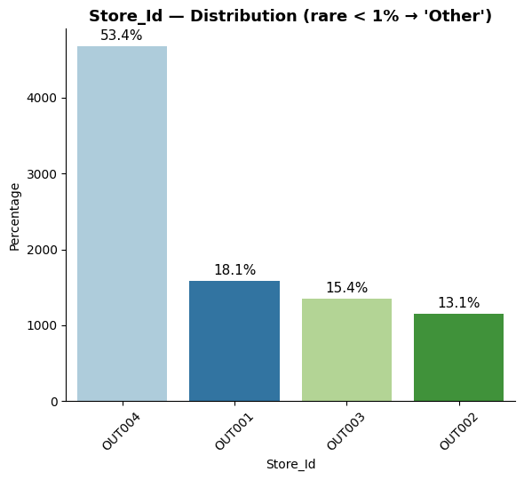

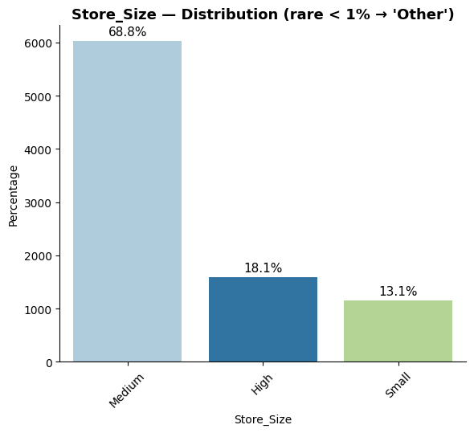

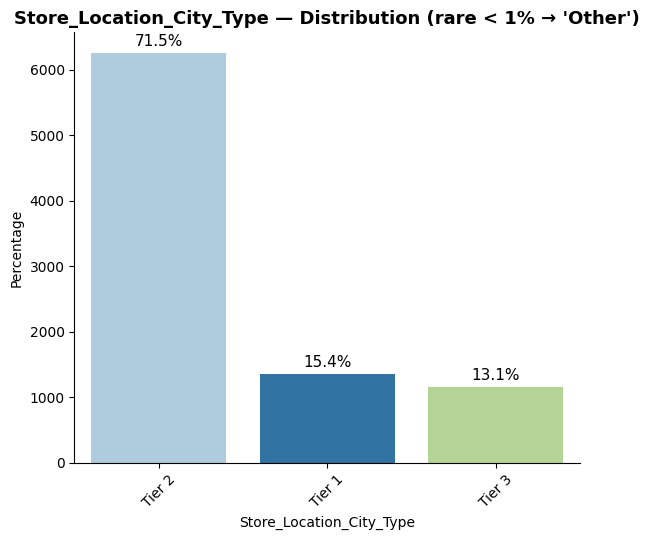

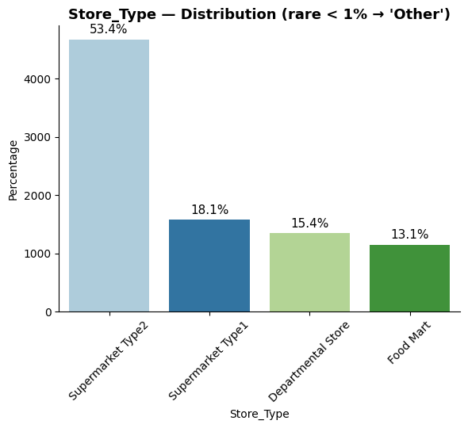

```python
# Plot labeled barplots for each categorical variable
for col in categorical_features:
    # Skip IDs if they are not meaningful for visualization
    if col not in ["Product_Id" ]:
        labeled_barplot(
            data,
            feature=col,
            perc=True,           # Display percentages
            top=None,            # Show all categories
            orient="v",          # Vertical bars
            min_pct=0.01,        # Group rare categories under "Other"
            font_size=11
        )
```

## 🧭 Univariate Analysis — Observations and Insights

### 🔹 Numerical Variables

#### **Product_Weight**

- The distribution of product weights is approximately **normal**, centered around 12.6 kg.
- The **mean (12.65)** and **median (12.66)** are almost identical, confirming **symmetry**.
- A few **outliers** exist at both ends, but they appear to be legitimate observations (e.g., smaller or heavier products).
- Overall, the feature is well-behaved and can be used directly for modeling without transformation.

#### **Product_Allocated_Area**

- The allocated area ratio is **right-skewed**, with most products occupying a **small display area**.
- The **mean (0.07)** is greater than the **median (0.06)**, confirming the positive skew.
- There are several **high outliers**, representing premium or high-visibility products that take up more shelf space.
- This skewness may benefit from a **log transformation** during modeling to stabilize variance.

#### **Product_MRP (Maximum Retail Price)**

- The MRP distribution follows an **approximately normal** pattern, with a mean around **147 USD**.
- A few products have significantly higher prices (>250 USD), but they are not extreme outliers.
- The **mean and median are nearly equal**, suggesting price data is balanced and not heavily influenced by extremes.

#### **Product_Store_Sales_Total (Target Variable)**

- The total product-store sales also display a **near-normal** distribution, centered around **3,464 units**.
- The mean and median are very close, suggesting **symmetry and consistency** across store sales.
- Only a few points deviate as mild outliers (possibly top-performing items).
- The feature’s normality indicates that **linear relationships and tree-based models** may both perform well.

### 🔹 Categorical Variables

#### **Product_Sugar_Content**

- The majority of products are labeled **Low Sugar (≈56%)**, followed by **Regular (≈26%)** and **No Sugar (≈17%)**.
- The dominance of *Low Sugar* options reflects an emphasis on **health-conscious offerings**.
- The category labeled *reg* is minimal (<2%) and may represent **data entry inconsistency**; it should be cleaned or merged with *Regular*.

#### **Store_Id**

- Store **OUT004** dominates with **53.4% of total records**, indicating it is either the largest store or has more SKUs listed.
- The remaining stores (*OUT001*, *OUT002*, *OUT003*) share the rest of the data more evenly.
- This imbalance may require **store-level normalization** during modeling to avoid bias toward the most represented store.

#### **Store_Type**

- The chain mainly consists of **Supermarket Type2 (53.4%)**, followed by **Supermarket Type1 (18.1%)**, **Departmental Store (15.4%)**, and **Food Mart (13.1%)**.
- This reflects a business model heavily reliant on the supermarket format.
- Including store type as a categorical feature will likely improve model interpretability regarding format-based sales performance.

### ⚙️ Key Takeaways

- The data is **well-distributed and clean**.
- **Most numerical features follow a normal or mildly skewed distribution**, supporting robust model training.
- **Categorical features are informative**, revealing clear operational and product segmentation patterns.
- These univariate insights establish a strong foundation for **bivariate analysis and feature engineering** in the next phase.

## Bivariate Analysis

```python
# Set a consistent theme for all plots
sns.set_theme(style="whitegrid")

# -----------------------------
# Numeric ↔ Numeric
# -----------------------------
def scatter_with_trend(
    data, x, y, hue=None,
    sample=5000, alpha=0.3,
    trend="auto",           # 'auto' | 'lowess' | 'poly' | 'none'
    poly_degree=2,          # grado para la tendencia polinómica
    color_trend="black",
    linewidth=2.0
):
    """
    Scatter plot with an optional trend line.

    - If trend='lowess', it tries to use statsmodels LOWESS.
    - If trend='poly', it fits a polynomial regression of given degree.
    - If trend='auto', it uses LOWESS if statsmodels is installed, otherwise polynomial.
    - If trend='none', no trend line is drawn.
    """

    # Subset & sample
    cols = [x, y] + ([hue] if hue else [])
    df = data[cols].dropna()
    if sample and len(df) > sample:
        df = df.sample(sample, random_state=42)

    plt.figure(figsize=(7.5, 5.5))
    ax = sns.scatterplot(data=df, x=x, y=y, hue=hue, alpha=alpha, edgecolor=None)

    # Decide trend mode
    mode = trend
    if trend == "auto":
        try:
            import statsmodels.api as sm  # noqa
            mode = "lowess"
        except Exception:
            mode = "poly"

    # Plot LOWESS if available
    if mode == "lowess":
        # use statsmodels lowess explicitly (works even if seaborn doesn't find it)
        from statsmodels.nonparametric.smoothers_lowess import lowess
        xx = df[x].to_numpy()
        yy = df[y].to_numpy()
        # sort x for a clean line
        order = np.argsort(xx)
        smoothed = lowess(yy[order], xx[order], frac=0.25, it=1, return_sorted=True)
        ax.plot(smoothed[:, 0], smoothed[:, 1], color=color_trend, linewidth=linewidth, label="LOWESS")
    elif mode == "poly":
        # simple polynomial fit as fallback
        xx = df[x].to_numpy()
        yy = df[y].to_numpy()
        order = np.argsort(xx)
        coeffs = np.polyfit(xx, yy, deg=poly_degree)
        y_hat = np.polyval(coeffs, xx[order])
        ax.plot(xx[order], y_hat, color=color_trend, linewidth=linewidth, label=f"Poly (deg={poly_degree})")
    else:
        # 'none' -> no trend line
        pass

    ax.set_title(f"{y} vs {x}" + ("" if mode == "none" else f" (trend: {mode})"))
    if hue is None and mode in {"lowess", "poly"}:
        ax.legend(loc="best")
    plt.tight_layout()
    return ax

def hexbin_density(data, x, y, gridsize=30):
    """
    Hexbin density plot (fast for large datasets).
    """
    df = data[[x, y]].dropna()
    plt.figure(figsize=(7.5, 5.5))
    hb = plt.hexbin(df[x], df[y], gridsize=gridsize, cmap="viridis", mincnt=1)
    plt.colorbar(hb, label="count")
    plt.xlabel(x); plt.ylabel(y)
    plt.title(f"Hexbin density: {y} vs {x}")
    plt.tight_layout()

def corr_heatmap(data, numeric_cols):
    """
    Correlation heatmap for a list of numeric columns.
    """
    corr = data[numeric_cols].corr(numeric_only=True)
    plt.figure(figsize=(8, 6))
    ax = sns.heatmap(corr, annot=True, fmt=".2f", cmap="vlag", linewidths=.5)
    ax.set_title("Correlation Heatmap (numeric variables)")
    plt.tight_layout()
    return ax

# -----------------------------
# Categorical ↔ Numeric
# -----------------------------
def box_violin_numeric_by_category(data, cat, num, kind="box", show_points=False):
    """
    Boxplot/Violinplot of a numeric variable conditioned on a category.
    Optionally overlays jitter points for distribution detail.
    """
    df = data[[cat, num]].dropna()
    plt.figure(figsize=(9, 5.5))
    if kind == "violin":
        ax = sns.violinplot(data=df, x=cat, y=num, inner="quartile", cut=0)
    else:
        ax = sns.boxplot(data=df, x=cat, y=num, showmeans=True,
                         meanprops={"marker":"o","markerfacecolor":"white","markeredgecolor":"black"})
    if show_points:
        sns.stripplot(data=df, x=cat, y=num, color="black", alpha=0.25, dodge=True)
    ax.set_title(f"{num} by {cat}")
    ax.tick_params(axis="x", rotation=30)
    plt.tight_layout()
    return ax

def mean_ci_bar(data, cat, num, estimator="mean", ci=95, order=None, top=None):
    """
    Barplot of an aggregate (mean by default) with confidence intervals.
    You can optionally plot only the top-N categories by sample size.
    """
    df = data[[cat, num]].dropna()
    if top:
        top_levels = df[cat].value_counts().head(top).index
        df = df[df[cat].isin(top_levels)]
    plt.figure(figsize=(9, 5.5))
    ax = sns.barplot(data=df, x=cat, y=num, estimator=getattr(np, estimator), ci=ci, order=order)
    ax.set_title(f"{num} {estimator} by {cat} (±{ci}% CI)")
    ax.tick_params(axis="x", rotation=30)
    plt.tight_layout()
    return ax

# -----------------------------
# Categorical ↔ Categorical
# -----------------------------
def stacked_ratio_bar(data, cat1, cat2, normalize="index"):
    """
    Stacked ratio bars between two categorical variables.
    normalize='index' -> % row-wise; 'columns' -> % col-wise; None -> counts.
    """
    ctab = pd.crosstab(data[cat1], data[cat2], normalize=normalize)
    ctab.plot(kind="bar", stacked=True, figsize=(9, 5.5), colormap="tab20")
    plt.title(f"{cat1} vs {cat2} ({'ratio' if normalize else 'count'})")
    plt.ylabel("Ratio" if normalize else "Count")
    plt.tight_layout()

def cat_heatmap(data, cat1, cat2, normalize=None):
    """
    Heatmap using a crosstab between two categorical variables.
    normalize=None -> counts; 'index' or 'columns' for row/col proportions.
    """
    ctab = pd.crosstab(data[cat1], data[cat2], normalize=normalize)
    plt.figure(figsize=(8, 6))
    ax = sns.heatmap(ctab, annot=True, fmt=".2f" if normalize else "d", cmap="Blues")
    ax.set_title(f"Heatmap: {cat1} x {cat2} ({'ratio' if normalize else 'count'})")
    plt.tight_layout()
    return ax
```

```
Numeric: ['Product_Weight', 'Product_Allocated_Area', 'Product_MRP', 'Store_Establishment_Year', 'Product_Store_Sales_Total']
Categorical: ['Product_Id', 'Product_Sugar_Content', 'Product_Type', 'Store_Id', 'Store_Size', 'Store_Location_City_Type', 'Store_Type']
# Num–Num pairs: 6
# Cat–Num (vs target) pairs: 7
# Cat–Cat pairs: 21
Recommended Num–Num: [('Product_Weight', 'Product_MRP'), ('Product_Weight', 'Product_Allocated_Area'), ('Product_MRP', 'Product_Allocated_Area'), ('Store_Establishment_Year', 'Product_Allocated_Area'), ('Store_Establishment_Year', 'Product_MRP'), ('Store_Establishment_Year', 'Product_Weight')]
Recommended Cat–Num (target): [('Product_Type', 'Product_Store_Sales_Total'), ('Product_Sugar_Content', 'Product_Store_Sales_Total'), ('Store_Size', 'Product_Store_Sales_Total'), ('Store_Location_City_Type', 'Product_Store_Sales_Total'), ('Store_Type', 'Product_Store_Sales_Total'), ('Store_Id', 'Pro…
Recommended Cat–Cat: [('Store_Size', 'Store_Location_City_Type'), ('Store_Type', 'Store_Location_City_Type'), ('Store_Type', 'Store_Size'), ('Product_Type', 'Product_Sugar_Content'), ('Store_Id', 'Store_Type')]
```

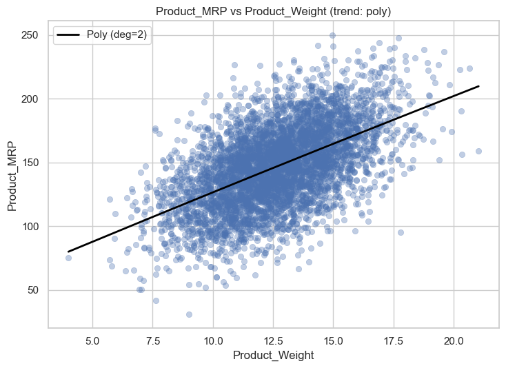

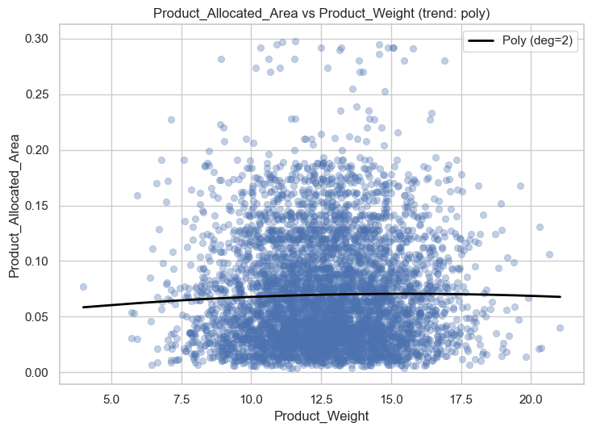

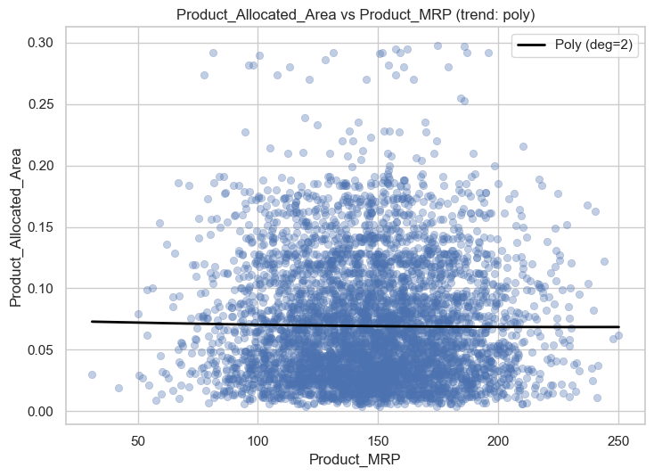

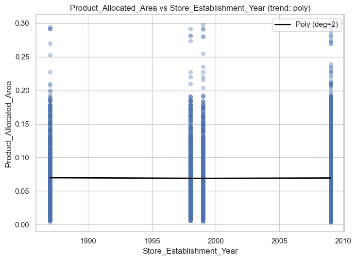

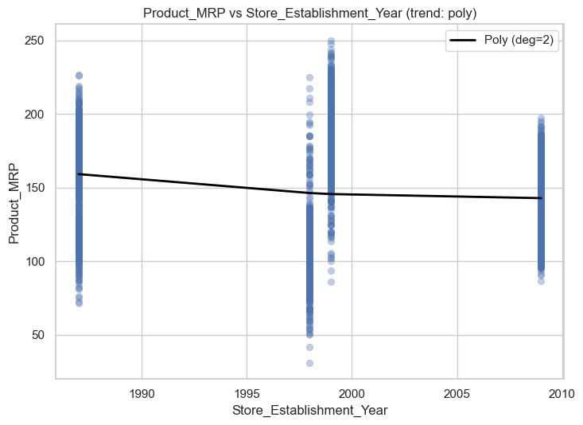

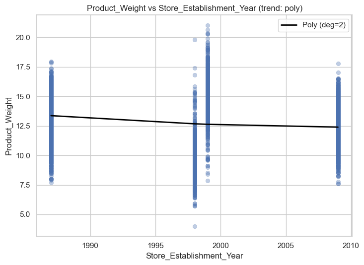

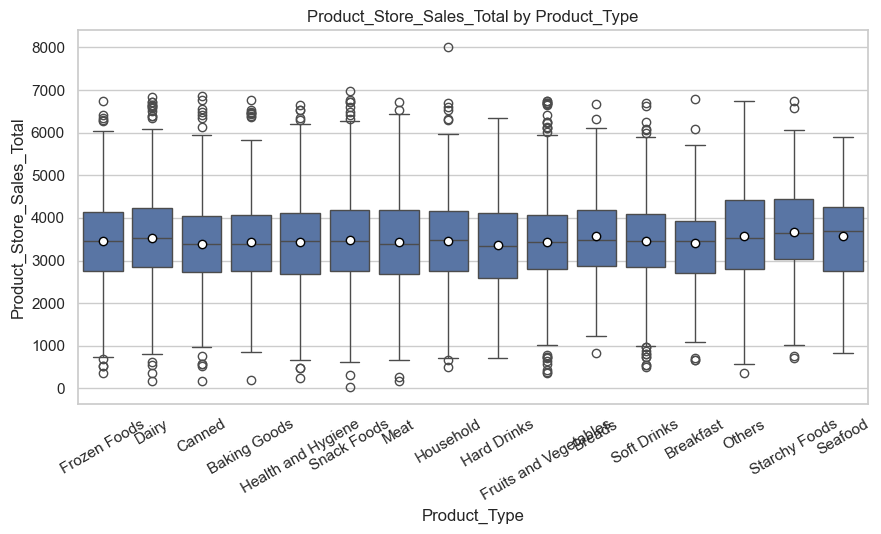

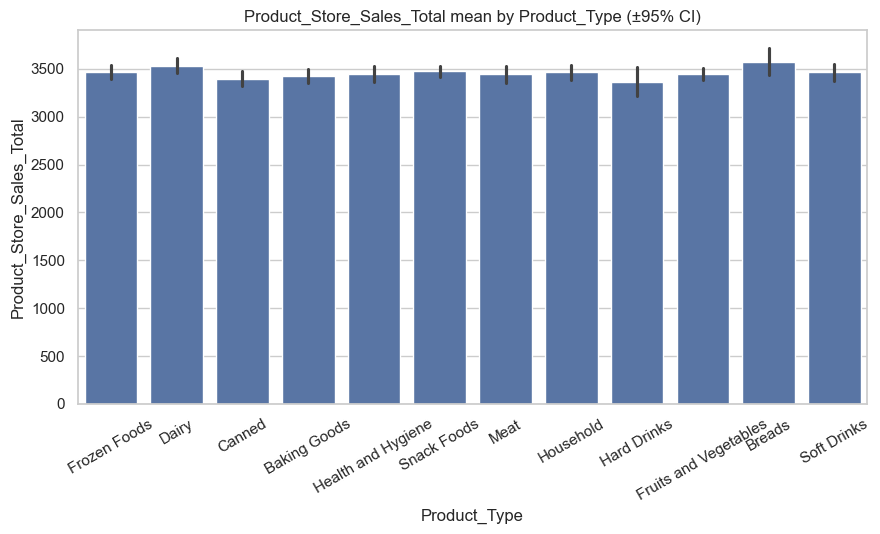

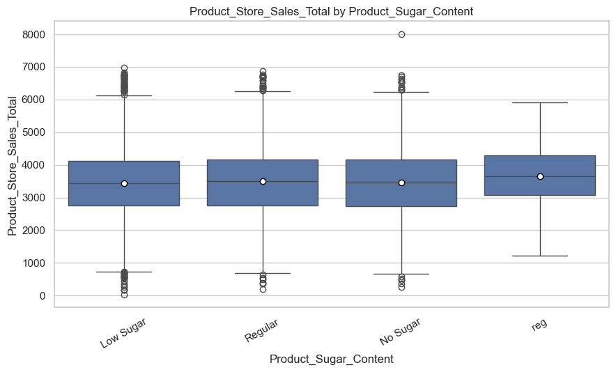

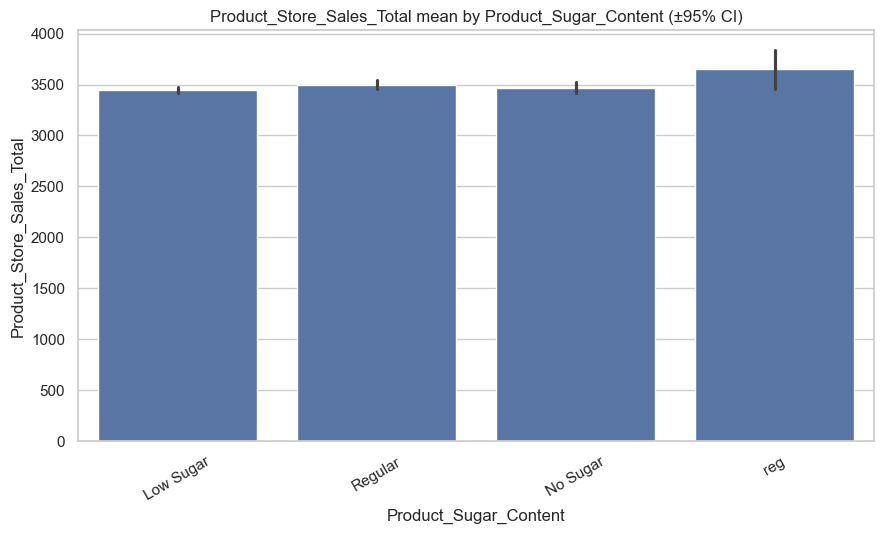

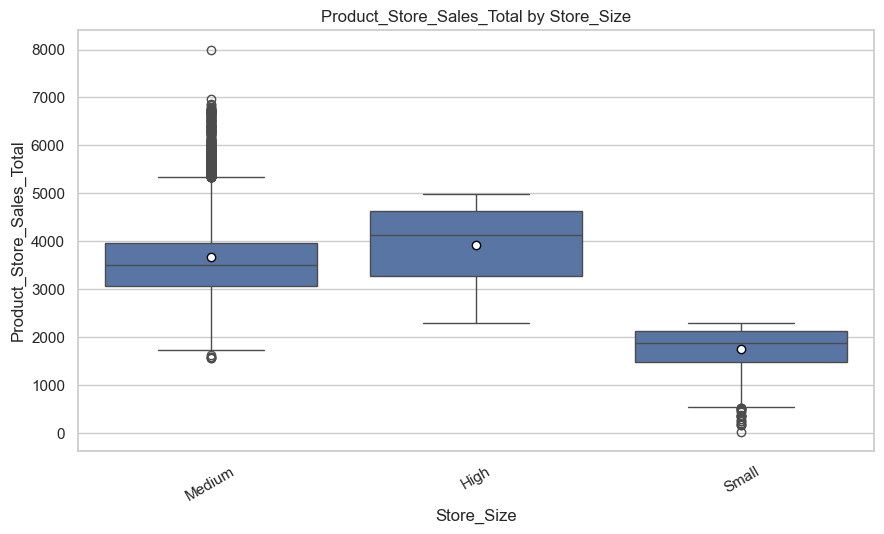

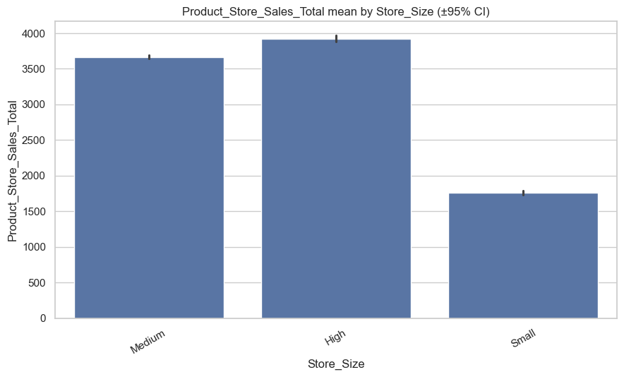

[16 more figures not shown]

```python
# -----------------------------
# 1) Identify variable types
# -----------------------------
# 'data' is our main DataFrame
target = "Product_Store_Sales_Total"

numeric_cols = data.select_dtypes(include=["int64", "float64"]).columns.tolist()
categorical_cols = data.select_dtypes(include=["object"]).columns.tolist()

# skip high-cardinality IDs when plotting categorical vars
id_like = {"Product_Id"}  # keep them if you want to review bias
cat_for_plots = [c for c in categorical_cols if c not in id_like]

print("Numeric:", numeric_cols)
print("Categorical:", categorical_cols)

# -----------------------------
# 2) Enumerate bivariate combos
# -----------------------------
from itertools import combinations

# (a) Numeric–Numeric: all pairwise combos among numeric variables
num_num_pairs = list(combinations([c for c in numeric_cols if c != target], 2))

# (b) Categorical–Numeric: each categorical vs target, and optionally vs other numeric vars
cat_num_pairs_target = [(c, target) for c in categorical_cols]
cat_num_pairs_all = [(c, n) for c in categorical_cols for n in numeric_cols]

# (c) Categorical–Categorical: pairs among categorical variables
cat_cat_pairs = list(combinations(categorical_cols, 2))

print(f"# Num–Num pairs: {len(num_num_pairs)}")
print(f"# Cat–Num (vs target) pairs: {len(cat_num_pairs_target)}")
print(f"# Cat–Cat pairs: {len(cat_cat_pairs)}")

# -----------------------------
# 3) Recommended pairs for SuperKart
# -----------------------------
# Focus on the most interpretable/useful combos for this dataset:

recommended = {
    "num_num": [
        ("Product_Weight", "Product_MRP"),
        ("Product_Weight", "Product_Allocated_Area"),
        ("Product_MRP", "Product_Allocated_Area"),
        ("Store_Establishment_Year", "Product_Allocated_Area"),
        ("Store_Establishment_Year", "Product_MRP"),
        ("Store_Establishment_Year", "Product_Weight"),
    ],
    "cat_num_target": [
        ("Product_Type", target),
        ("Product_Sugar_Content", target),
        ("Store_Size", target),
        ("Store_Location_City_Type", target),
        ("Store_Type", target),
        # keep Store_Id if you want to reveal store-level bias:
        ("Store_Id", target),
    ],
    "cat_cat": [
        ("Store_Size", "Store_Location_City_Type"),
        ("Store_Type", "Store_Location_City_Type"),
        ("Store_Type", "Store_Size"),
        ("Product_Type", "Product_Sugar_Content"),
        ("Store_Id", "Store_Type"),
    ]
}

print("Recommended Num–Num:", recommended["num_num"])
print("Recommended Cat–Num (target):", recommended["cat_num_target"])
print("Recommended Cat–Cat:", recommended["cat_cat"])

# -----------------------------
# 4) Plot helpers by pair type
# -----------------------------
# (a) Numeric–Numeric: scatter + LOWESS; if relation is dense, try hexbin
for x, y in recommended["num_num"]:
    scatter_with_trend(
        data, x, y,
        trend="auto",
        poly_degree=2,
        alpha=0.35
    )
    plt.show()
    # hexbin_density(data, x, y); plt.show()

# (b) Categorical–Numeric (vs target): box/violin and mean+CI
for cat, num in recommended["cat_num_target"]:
    # Boxplot (use violin for shape)
    box_violin_numeric_by_category(data, cat=cat, num=num, kind="box", show_points=False)
    plt.show()
    # Mean with 95% CI (top levels if high cardinality)
    mean_ci_bar(data, cat=cat, num=num, estimator="mean", ci=95, top=12)
    plt.show()

# (c) Categorical–Categorical: stacked ratio and heatmap
for c1, c2 in recommended["cat_cat"]:
    stacked_ratio_bar(data, c1, c2, normalize="index")
    plt.show()
    cat_heatmap(data, c1, c2, normalize="index")
    plt.show()
```

## 🔍 Bivariate Analysis — Observations and Insights

### 1️⃣ Numeric vs Numeric Relationships

#### **Product_Weight vs Product_MRP**

- There is a **moderate positive relationship** between product weight and price (MRP).
- Heavier products tend to be priced higher, as expected due to material and packaging costs.
- The relationship is not perfectly linear but consistent, confirming **pricing proportionality** with weight.

#### **Product_Weight vs Product_Allocated_Area**

- The relationship between product weight and shelf area is **weak and nearly flat**.
- Products with higher weight do not necessarily occupy more shelf space.
- Indicates **weight and shelf space are determined by different merchandising strategies** (e.g., stacking efficiency or category layout).

#### **Product_MRP vs Product_Allocated_Area**

- The correlation is very weak and almost constant across the range.
- High-priced products do not consistently occupy larger display areas.
- Suggests **premium pricing does not directly translate to shelf prominence**.

### 2️⃣ Categorical vs Numeric (Target: Product_Store_Sales_Total)

#### **Store_Size vs Sales**

- A clear trend appears: **High > Medium > Small** in terms of mean sales.
- Larger stores naturally generate more sales due to greater inventory and customer flow.
- This relationship is **strong and intuitive**, indicating **store size is a key driver of sales volume**.

#### **Store_Location_City_Type vs Sales**

- Stores in **Tier 1 cities** have the **highest average sales**, followed by **Tier 2**, while **Tier 3** stores underperform significantly.
- This highlights **urban customer density and income level** as critical sales factors.
- The sales gap between Tier 1 and Tier 3 suggests a strong **regional imbalance** in store performance.

#### **Store_Type vs Sales**

- **Departmental Stores** lead in mean sales, followed by **Supermarket Type1** and **Type2**; **Food Marts** perform the worst.
- Departmental stores likely benefit from **broader product ranges** and **higher average transaction values**.
- Confirms that **store format has a direct influence on profitability and sales potential**.

#### **Store_Id vs Sales**

- There are notable differences across stores:
  - **OUT003** and **OUT001** show higher average sales.
  - **OUT002** is the lowest-performing outlet.
- Indicates **store-specific factors** (e.g., location, management, or regional economy) have measurable effects on sales.

### 3️⃣ Categorical vs Categorical Relationships

#### **Store_Type vs Store_Location_City_Type**

- **Supermarket Type2** dominates in Tier 2 cities.
- **Food Marts** are concentrated in Tier 3.
- **Departmental Stores** primarily serve Tier 1 markets.
- Suggests **each store format is strategically aligned to the market segment and city demographic**.

#### **Product_Type vs Product_Sugar_Content**

- Distinct category tendencies:
  - *Soft Drinks* and *Snack Foods* have high proportions of **Regular** and **Low Sugar** variants.
  - *Health and Hygiene* and *Household* products show **No Sugar**, as expected (non-edible items).
- The “reg” label appears only in specific product types, reaffirming it as a **data labeling error**.
- Overall, sugar content strongly differentiates **food-related categories**, confirming **product type relevance in nutritional profiling**.

#### **Store_Id vs Store_Type**

- Each Store_Id maps almost uniquely to a Store_Type:
  - **OUT004 → Supermarket Type2**
  - **OUT003 → Departmental Store**
  - **OUT001 → Supermarket Type1**
  - **OUT002 → Food Mart**
- Confirms **consistent internal coding**, but also suggests **redundancy** — these two variables convey nearly identical information.

### ⚙️ Key Takeaways

These insights provide a strong foundation for **multivariate modeling**, guiding feature selection and business strategy in the SuperKart dataset.

# **Data Preprocessing**

```python
# Fix inconsistent category labels
data.Product_Sugar_Content.replace(to_replace=["reg"], value=["Regular"], inplace=True)
```

```python
# Check the value counts to confirm the fix
data.Product_Sugar_Content.value_counts()
```

```
Product_Sugar_Content
Low Sugar    4885
Regular      2359
No Sugar     1519
Name: count, dtype: int64
```

```python
# Create a new feature extracting the first two characters from Product_Id
data["Product_ID_Code"] = data["Product_Id"].str[:2]
data.head()
```

|  | Product_Id | Product_Weight | Product_Sugar_Content | Product_Allocated_Area | Product_Type | Product_MRP | Store_Id | Store_Establishment_Year | Store_Size | Store_Location_City_Type | Store_Type | Product_Store_Sales_Total | Product_ID_Code |
| --- | --- | --- | --- | --- | --- | --- | --- | --- | --- | --- | --- | --- | --- |
| 0 | FD6114 | 12.66 | Low Sugar | 0.027 | Frozen Foods | 117.08 | OUT004 | 2009 | Medium | Tier 2 | Supermarket Type2 | 2842.40 | FD |
| 1 | FD7839 | 16.54 | Low Sugar | 0.144 | Dairy | 171.43 | OUT003 | 1999 | Medium | Tier 1 | Departmental Store | 4830.02 | FD |
| 2 | FD5075 | 14.28 | Regular | 0.031 | Canned | 162.08 | OUT001 | 1987 | High | Tier 2 | Supermarket Type1 | 4130.16 | FD |
| 3 | FD8233 | 12.10 | Low Sugar | 0.112 | Baking Goods | 186.31 | OUT001 | 1987 | High | Tier 2 | Supermarket Type1 | 4132.18 | FD |
| 4 | NC1180 | 9.57 | No Sugar | 0.010 | Health and Hygiene | 123.67 | OUT002 | 1998 | Small | Tier 3 | Food Mart | 2279.36 | NC |

```python
# Check the unique values of the new feature
data["Product_ID_Code"].unique()
```

```
array(['FD', 'NC', 'DR'], dtype=object)
```

```python
# Check the unique values of Product_Type for a specific Product_ID_Code
data.loc[data.Product_ID_Code=="FD","Product_Type"].unique()
```

```
array(['Frozen Foods', 'Dairy', 'Canned', 'Baking Goods', 'Snack Foods',
       'Meat', 'Fruits and Vegetables', 'Breads', 'Breakfast',
       'Starchy Foods', 'Seafood'], dtype=object)
```

```python
# Check the unique values of Product_Type for another specific Product_ID_Code
data.loc[data.Product_ID_Code=="NC","Product_Type"].unique()
```

```
array(['Health and Hygiene', 'Household', 'Others'], dtype=object)
```

```python
# Check the unique values of Product_Type for another specific Product_ID_Code
data.loc[data.Product_ID_Code=="DR","Product_Type"].unique()
```

```
array(['Hard Drinks', 'Soft Drinks'], dtype=object)
```

```python
# Create a new feature representing the age of the store in years
data["Store_Age_Years"] = 2025 - data.Store_Establishment_Year
```

```python
# List of perishable product types
perishables = [
    "Dairy",
    "Meat",
    "Fruits and Vegetables",
    "Breakfast",
    "Breads",
    "Seafood",
]
```

```python
# Function to categorize products as Perishables or Non Perishables
def change(x):
    if x in perishables:
        return "Perishables"
    else:
        return "Non Perishables"
```

```python
# Create a new feature categorizing Product_Type into Perishables and Non Perishables
data['Product_Type_Category'] = data['Product_Type'].apply(change)
```

```python
# Display the first few rows of the updated DataFrame
data.head()
```

|  | Product_Id | Product_Weight | Product_Sugar_Content | Product_Allocated_Area | Product_Type | Product_MRP | Store_Id | Store_Establishment_Year | Store_Size | Store_Location_City_Type | Store_Type | Product_Store_Sales_Total | Product_ID_Code | Store_Age_Years | Product_Type_Category |
| --- | --- | --- | --- | --- | --- | --- | --- | --- | --- | --- | --- | --- | --- | --- | --- |
| 0 | FD6114 | 12.66 | Low Sugar | 0.027 | Frozen Foods | 117.08 | OUT004 | 2009 | Medium | Tier 2 | Supermarket Type2 | 2842.40 | FD | 16 | Non Perishables |
| 1 | FD7839 | 16.54 | Low Sugar | 0.144 | Dairy | 171.43 | OUT003 | 1999 | Medium | Tier 1 | Departmental Store | 4830.02 | FD | 26 | Perishables |
| 2 | FD5075 | 14.28 | Regular | 0.031 | Canned | 162.08 | OUT001 | 1987 | High | Tier 2 | Supermarket Type1 | 4130.16 | FD | 38 | Non Perishables |
| 3 | FD8233 | 12.10 | Low Sugar | 0.112 | Baking Goods | 186.31 | OUT001 | 1987 | High | Tier 2 | Supermarket Type1 | 4132.18 | FD | 38 | Non Perishables |
| 4 | NC1180 | 9.57 | No Sugar | 0.010 | Health and Hygiene | 123.67 | OUT002 | 1998 | Small | Tier 3 | Food Mart | 2279.36 | NC | 27 | Non Perishables |

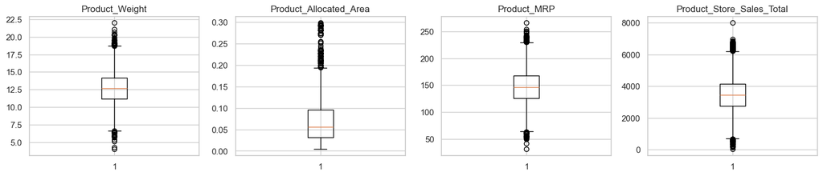

```python
# Visualize boxplots for all numeric variables to check for outliers
numeric_columns = data.select_dtypes(include=np.number).columns.tolist()
numeric_columns.remove("Store_Establishment_Year")
numeric_columns.remove("Store_Age_Years")


plt.figure(figsize=(15, 12))

for i, variable in enumerate(numeric_columns):
    plt.subplot(4, 4, i + 1)
    plt.boxplot(data[variable], whis=1.5)
    plt.tight_layout()
    plt.title(variable)

plt.show()
```

```python
# Drop unnecessary columns that won't be used in modeling
data = data.drop(["Product_Id","Product_Type","Store_Id","Store_Establishment_Year"], axis=1)
```

```python
# Display the shape of the updated DataFrame
data.shape
```

```
(8763, 11)
```

```python
# Display the first few rows of the updated DataFrame
data.head()
```

|  | Product_Weight | Product_Sugar_Content | Product_Allocated_Area | Product_MRP | Store_Size | Store_Location_City_Type | Store_Type | Product_Store_Sales_Total | Product_ID_Code | Store_Age_Years | Product_Type_Category |
| --- | --- | --- | --- | --- | --- | --- | --- | --- | --- | --- | --- |
| 0 | 12.66 | Low Sugar | 0.027 | 117.08 | Medium | Tier 2 | Supermarket Type2 | 2842.40 | FD | 16 | Non Perishables |
| 1 | 16.54 | Low Sugar | 0.144 | 171.43 | Medium | Tier 1 | Departmental Store | 4830.02 | FD | 26 | Perishables |
| 2 | 14.28 | Regular | 0.031 | 162.08 | High | Tier 2 | Supermarket Type1 | 4130.16 | FD | 38 | Non Perishables |
| 3 | 12.10 | Low Sugar | 0.112 | 186.31 | High | Tier 2 | Supermarket Type1 | 4132.18 | FD | 38 | Non Perishables |
| 4 | 9.57 | No Sugar | 0.010 | 123.67 | Small | Tier 3 | Food Mart | 2279.36 | NC | 27 | Non Perishables |

```python
# Separating features and target variable
X = data.drop("Product_Store_Sales_Total", axis=1)
y = data["Product_Store_Sales_Total"]
```

```python
# Splitting the dataset into training and testing sets
X_train, X_test, y_train, y_test = train_test_split(X, y, test_size=0.3, random_state=42, shuffle=True)
```

```python
# Displaying the shapes of the training and testing sets
X_train.shape, X_test.shape, y_train.shape, y_test.shape
```

```
((6134, 10), (2629, 10), (6134,), (2629,))
```

```python
# --- Robust dtype detection ---
# Categorical = object or pandas 'category'
categorical_features = X.select_dtypes(include=["object", "category"]).columns.tolist()

# Numeric = anything recognized by pandas as a number (int/float/nullable)
numeric_features = X.select_dtypes(include=["number"]).columns.tolist()

print("Categorical features:", categorical_features)
print("Numeric features:", numeric_features)
```

```
Categorical features: ['Product_Sugar_Content', 'Store_Size', 'Store_Location_City_Type', 'Store_Type', 'Product_ID_Code', 'Product_Type_Category']
Numeric features: ['Product_Weight', 'Product_Allocated_Area', 'Product_MRP', 'Store_Age_Years']
```

```python
# --- OneHotEncoder: keep dense output regardless of sklearn version ---
try:
    ohe = OneHotEncoder(handle_unknown="ignore", sparse_output=False)
except TypeError:
    # fallback for older scikit-learn where 'sparse_output' doesn't exist
    ohe = OneHotEncoder(handle_unknown="ignore", sparse=False)

# --- Pipelines for each data type ---
numeric_pipeline = Pipeline(
    steps=[
        ("imputer", SimpleImputer(strategy="median")),
        ("scaler", StandardScaler())
    ]
)

categorical_pipeline = Pipeline(
    steps=[
        ("imputer", SimpleImputer(strategy="most_frequent")),
        ("encoder", ohe)
    ]
)

# --- Option A (clear & explicit): ColumnTransformer ---
preprocessor = ColumnTransformer(
    transformers=[
        ("num", numeric_pipeline, numeric_features),
        ("cat", categorical_pipeline, categorical_features),
    ],
    remainder="drop"   # drop anything not listed above (safer for reproducibility)
)

# (Alternative) Option B using make_column_transformer (equivalent):
# preprocessor = make_column_transformer(
#     (numeric_pipeline, numeric_features),
#     (categorical_pipeline, categorical_features),
#     remainder="drop"
# )
```

## 🧩 Data Preprocessing — Observations and Insights

### 1️⃣ Overview

The preprocessing stage combined **data cleaning**, **feature engineering**, and **pipeline-based transformations** to prepare the dataset for modeling.  
A unified `ColumnTransformer` was implemented to ensure consistent preprocessing for both numeric and categorical data, minimizing data leakage and maximizing reproducibility.

### 2️⃣ Data Cleaning and Feature Engineering

#### **Category Label Fix**

- The inconsistent label `"reg"` in `Product_Sugar_Content` was replaced with `"Regular"` to ensure uniformity.
- Verified using `value_counts()`, confirming all sugar-level categories are now clean and standardized (`Low Sugar`, `Regular`, `No Sugar`).

#### **New Engineered Features**

1. **`Product_ID_Code`**
   - Extracted the first two characters from `Product_Id` (e.g., “FD”, “DR”, “NC”) to group items by product family.
   - This variable helps capture brand-level or manufacturing-level variations that may influence sales.
   - Example mapping observed:
     - `FD` → Frozen, Dairy, Breads, Meat
     - `NC` → Health, Household
     - `DR` → Drinks
2. **`Store_Age_Years`**
   - Calculated as `2025 - Store_Establishment_Year`.
   - Represents the number of years a store has been operating.
   - Useful to test if **store maturity** influences sales performance or customer trust.
3. **`Product_Type_Category` (Perishables vs Non-Perishables)**
   - Created based on a predefined list of perishable items:  
     `["Dairy", "Meat", "Fruits and Vegetables", "Breakfast", "Breads", "Seafood"]`
   - All other products were categorized as **“Non-Perishables.”**
   - This grouping reduces noise among product subcategories and allows the model to capture differences in inventory dynamics and shelf life.

### 4️⃣ Feature Transformation with ColumnTransformer

#### **Numeric Pipeline**

- **Imputer:** `SimpleImputer(strategy="median")` handles missing numeric data without being affected by outliers.
- **Scaler:** `StandardScaler()` ensures all numeric features (e.g., `Product_MRP`, `Product_Weight`) have mean 0 and unit variance, which helps models converge faster and avoids dominance by high-magnitude features.

#### **Categorical Pipeline**

- **Imputer:** `SimpleImputer(strategy="most_frequent")` fills missing categorical values with the mode of each column.
- **Encoder:** `OneHotEncoder(handle_unknown="ignore", sparse_output=False)` converts categorical variables (e.g., `Store_Type`, `Store_Size`, `Product_Sugar_Content`) into binary columns while safely ignoring unseen categories at inference time.

#### **Unified Preprocessor**

```
preprocessor = ColumnTransformer(
    transformers=[
        ("num", numeric_pipeline, numeric_features),
        ("cat", categorical_pipeline, categorical_features),
    ],
    remainder="drop"
)
```

# **Model Building**

## Define functions for Model Evaluation

```python
# Adjusted R² calculation
def adj_r2_score_from_prediction(n: int, k: int, r2: float) -> float:
    """
    Adjusted R² given:
    - n: number of samples used for evaluation
    - k: number of predictors (AFTER preprocessing/encoding)
    - r2: plain R²
    """
    # Guard against division by zero when n - k - 1 <= 0
    denom = max(n - k - 1, 1)
    return 1.0 - ((1.0 - r2) * (n - 1) / denom)

# Effective k calculation for pipelines
def _effective_k_from_pipeline(model, X) -> int:
    """
    Compute effective number of predictors (k) for a fitted Pipeline.
    If a 'preprocess' step exists, we use its transformed shape.
    Otherwise we fallback to X.shape[1].
    """
    try:
        pre = getattr(model, "named_steps", {}).get("preprocess", None)
        if pre is not None:
            # model must be already fitted; transform uses train-fit params
            Xt = pre.transform(X)
            return Xt.shape[1]
    except Exception:
        pass
    # Fallback (no preprocess or cannot transform)
    return X.shape[1]

# Model performance function for regression
def model_performance_regression(model, predictors, target) -> pd.DataFrame:
    """
    Compute regression metrics for a (fitted) model or pipeline:
    - RMSE, MAE, R², Adjusted R², MAPE

    model: fitted regressor or sklearn Pipeline (e.g., preprocess + model)
    predictors: X matrix BEFORE preprocessing (pipeline will handle it)
    target: y vector/series
    """
    # Predict with the pipeline/model
    pred = model.predict(predictors)

    r2 = r2_score(target, pred)
    rmse = float(np.sqrt(mean_squared_error(target, pred)))
    mae = float(mean_absolute_error(target, pred))
    mape = float(mean_absolute_percentage_error(target, pred))

    # Adjusted R² with k derived after preprocessing
    n = predictors.shape[0]
    k = _effective_k_from_pipeline(model, predictors)
    adjr2 = adj_r2_score_from_prediction(n=n, k=k, r2=r2)

    df_perf = pd.DataFrame(
        {
            "RMSE": [rmse],
            "MAE": [mae],
            "R-squared": [float(r2)],
            "Adj. R-squared": [float(adjr2)],
            "MAPE": [mape],
            "n_samples": [int(n)],
            "k_effective": [int(k)],
        }
    )
    return df_perf
```

The ML models to be built can be any two out of the following:

1. Decision Tree
2. Bagging
3. Random Forest
4. AdaBoost
5. Gradient Boosting
6. XGBoost

```python
# Check if xgboost is installed
try:
    HAS_XGB = True
except Exception:
    HAS_XGB = False


def evaluate_models_with_custom_metrics(
    X_train, y_train, X_test, y_test, preprocessor,
    random_state: int = 42, cv_splits: int = 5, n_jobs: int = -1
) -> Tuple[pd.DataFrame, Pipeline]:
    """
    Train and evaluate Decision Tree, Bagging, Random Forest, AdaBoost,
    Gradient Boosting, and XGBoost (if available) using a unified preprocessing pipeline.

    Returns:
    - results_df: leaderboard sorted by Test RMSE with CV RMSE mean/std and
                  Test RMSE/MAE/R²/AdjR²/MAPE + n,k.
    - best_pipe:  fitted pipeline of the best model by Test RMSE.
    """

    models: Dict[str, object] = {
        "DecisionTree": DecisionTreeRegressor(random_state=random_state),
        "Bagging": BaggingRegressor(n_estimators=200, random_state=random_state, n_jobs=n_jobs),
        "RandomForest": RandomForestRegressor(n_estimators=300, random_state=random_state, n_jobs=n_jobs),
        "AdaBoost": AdaBoostRegressor(n_estimators=300, learning_rate=0.05, random_state=random_state),
        "GradientBoosting": GradientBoostingRegressor(n_estimators=300, learning_rate=0.05, max_depth=3, random_state=random_state),
    }
    if HAS_XGB:
        models["XGBoost"] = XGBRegressor(
            objective="reg:squarederror",
            n_estimators=600, learning_rate=0.05, max_depth=6,
            subsample=0.8, colsample_bytree=0.8, reg_lambda=1.0,
            n_jobs=n_jobs, random_state=random_state, tree_method="hist"
        )

    results = []
    best_name, best_rmse, best_pipe = None, np.inf, None
    kf = KFold(n_splits=cv_splits, shuffle=True, random_state=random_state)

    for name, est in models.items():
        pipe = Pipeline([("preprocess", preprocessor), ("model", est)])

        # CV RMSE on training set
        cv_scores = cross_val_score(
            pipe, X_train, y_train,
            scoring="neg_root_mean_squared_error",
            cv=kf, n_jobs=n_jobs
        )
        cv_rmse_mean = float(-cv_scores.mean())
        cv_rmse_std  = float(cv_scores.std())

        # Fit and evaluate on test with full metric suite
        pipe.fit(X_train, y_train)
        perf = model_performance_regression(pipe, X_test, y_test).iloc[0].to_dict()

        row = {
            "model": name,
            "cv_rmse_mean": cv_rmse_mean,
            "cv_rmse_std": cv_rmse_std,
            "test_rmse": perf["RMSE"],
            "test_mae": perf["MAE"],
            "test_r2": perf["R-squared"],
            "test_adj_r2": perf["Adj. R-squared"],
            "test_mape": perf["MAPE"],
            "n_test": int(perf["n_samples"]),
            "k_effective": int(perf["k_effective"]),
        }
        results.append(row)

        if perf["RMSE"] < best_rmse:
            best_rmse = perf["RMSE"]
            best_name = name
            best_pipe = pipe

    results_df = pd.DataFrame(results).sort_values("test_rmse").reset_index(drop=True)
    print(f"Best model by Test RMSE: {best_name} (RMSE = {best_rmse:.3f})")
    if not HAS_XGB:
        print("Note: XGBoost was skipped because 'xgboost' is not installed.")
    return results_df, best_pipe
```

```python
# Evaluate models and get the leaderboard
leaderboard, best_model = evaluate_models_with_custom_metrics(
    X_train, y_train, X_test, y_test, preprocessor,
    random_state=42, cv_splits=5, n_jobs=-1
)

leaderboard  # Display the leaderboard
```

```
Best model by Test RMSE: RandomForest (RMSE = 282.701)
```

|  | model | cv_rmse_mean | cv_rmse_std | test_rmse | test_mae | test_r2 | test_adj_r2 | test_mape | n_test | k_effective |
| --- | --- | --- | --- | --- | --- | --- | --- | --- | --- | --- |
| 0 | RandomForest | 291.736994 | 20.845229 | 282.701362 | 106.843682 | 0.929623 | 0.929029 | 0.038883 | 2629 | 22 |
| 1 | Bagging | 292.721101 | 20.705200 | 283.157203 | 107.348400 | 0.929396 | 0.928800 | 0.039055 | 2629 | 22 |
| 2 | XGBoost | 304.322843 | 15.869530 | 293.363133 | 127.009633 | 0.924214 | 0.923575 | 0.045798 | 2629 | 22 |
| 3 | GradientBoosting | 314.160573 | 21.181424 | 301.247656 | 136.633763 | 0.920086 | 0.919411 | 0.051118 | 2629 | 22 |
| 4 | DecisionTree | 406.776303 | 24.409774 | 388.029106 | 135.941579 | 0.867412 | 0.866293 | 0.049736 | 2629 | 22 |
| 5 | AdaBoost | 483.141647 | 11.260480 | 480.116760 | 375.442619 | 0.797012 | 0.795299 | 0.132692 | 2629 | 22 |

```python
# pick top-2 by test_rmse
top2 = leaderboard.nsmallest(2, "test_rmse")["model"].tolist()
top2
```

```
['RandomForest', 'Bagging']
```

# **Model Performance Improvement - Hyperparameter Tuning**

### The best models where RandomForest and Bagging

We will tune those models

```python
# Hyperparameter tuning for Random Forest using RandomizedSearchCV

cv = KFold(n_splits=5, shuffle=True, random_state=42)

rf_pipe = Pipeline([
    ("preprocess", preprocessor),
    ("model", RandomForestRegressor(random_state=42, n_jobs=-1))
])

rf_param_dist = {
    "model__n_estimators": [300, 500, 800, 1000],
    "model__max_depth": [None, 10, 15, 20, 30],
    "model__min_samples_split": [2, 5, 10, 20],
    "model__min_samples_leaf": [1, 2, 4, 8],
    "model__max_features": ["sqrt", "log2", 0.5, 0.7, 0.9],
    "model__bootstrap": [True],   # False can lead to overfitting
}

rf_search = RandomizedSearchCV(
    rf_pipe,
    param_distributions=rf_param_dist,
    n_iter=50,  # number of random combinations to try
    scoring="neg_root_mean_squared_error",
    cv=cv,
    n_jobs=-1,
    random_state=42,
    verbose=1
)

rf_search.fit(X_train, y_train)

print("Best RF params:", rf_search.best_params_)
print("Best RF CV RMSE:", -rf_search.best_score_)

rf_tuned_perf = model_performance_regression(rf_search.best_estimator_, X_test, y_test)
rf_tuned_perf
```

```
Fitting 5 folds for each of 50 candidates, totalling 250 fits
Best RF params: {'model__n_estimators': 500, 'model__min_samples_split': 5, 'model__min_samples_leaf': 4, 'model__max_features': 0.9, 'model__max_depth': 20, 'model__bootstrap': True}
Best RF CV RMSE: 287.3779027980666
```

|  | RMSE | MAE | R-squared | Adj. R-squared | MAPE | n_samples | k_effective |
| --- | --- | --- | --- | --- | --- | --- | --- |
| 0 | 276.804588 | 104.28994 | 0.932528 | 0.931959 | 0.039303 | 2629 | 22 |

```python
# Hyperparameter tuning for Bagging using RandomizedSearchCV
base_tree = DecisionTreeRegressor(random_state=42)

bag_pipe = Pipeline([
    ("preprocess", preprocessor),
    ("model", BaggingRegressor(
        # base_estimator was renamed to estimator in sklearn 1.2+
        **({"estimator": base_tree} if "estimator" in BaggingRegressor().__dict__ else {"base_estimator": base_tree}),
        n_estimators=300,
        random_state=42,
        n_jobs=-1
    ))
])

bag_param_dist = {
    "model__n_estimators": [200, 300, 500, 800],
    # base tree-level
    "model__estimator__max_depth": [None, 8, 12, 16, 20] if "estimator" in BaggingRegressor().__dict__ else
                                   "model__base_estimator__max_depth",
    "model__estimator__min_samples_split": [2, 5, 10, 20] if "estimator" in BaggingRegressor().__dict__ else
                                           "model__base_estimator__min_samples_split",
    "model__estimator__min_samples_leaf": [1, 2, 4, 8] if "estimator" in BaggingRegressor().__dict__ else
                                          "model__base_estimator__min_samples_leaf",
    # bagging-level
    "model__max_samples": [0.6, 0.7, 0.8, 1.0],
    "model__max_features": [0.6, 0.8, 1.0],
    "model__bootstrap": [True],
    "model__bootstrap_features": [False, True],
    "model__oob_score": [True, False],
}

# Adjust param_dist keys
if "estimator" not in BaggingRegressor().__dict__:
    bag_param_dist = {
        "model__n_estimators": [200, 300, 500, 800],
        "model__base_estimator__max_depth": [None, 8, 12, 16, 20],
        "model__base_estimator__min_samples_split": [2, 5, 10, 20],
        "model__base_estimator__min_samples_leaf": [1, 2, 4, 8],
        "model__max_samples": [0.6, 0.7, 0.8, 1.0],
        "model__max_features": [0.6, 0.8, 1.0],
        "model__bootstrap": [True],
        "model__bootstrap_features": [False, True],
        "model__oob_score": [True, False],
    }

bag_search = RandomizedSearchCV(
    bag_pipe,
    param_distributions=bag_param_dist,
    n_iter=50,
    scoring="neg_root_mean_squared_error",
    cv=cv,
    n_jobs=-1,
    random_state=42,
    verbose=1
)

bag_search.fit(X_train, y_train)

print("Best Bagging params:", bag_search.best_params_)
print("Best Bagging CV RMSE:", -bag_search.best_score_)

bag_tuned_perf = model_performance_regression(bag_search.best_estimator_, X_test, y_test)
bag_tuned_perf
```

```
Fitting 5 folds for each of 50 candidates, totalling 250 fits
Best Bagging params: {'model__oob_score': True, 'model__n_estimators': 300, 'model__max_samples': 0.8, 'model__max_features': 1.0, 'model__estimator__min_samples_split': 2, 'model__estimator__min_samples_leaf': 2, 'model__estimator__max_depth': None, 'model__bootstrap_features': False, 'model__boots…
Best Bagging CV RMSE: 286.9880052862924
```

|  | RMSE | MAE | R-squared | Adj. R-squared | MAPE | n_samples | k_effective |
| --- | --- | --- | --- | --- | --- | --- | --- |
| 0 | 277.332545 | 103.242706 | 0.932271 | 0.931699 | 0.038122 | 2629 | 22 |

# **Model Performance Comparison, Final Model Selection, and Serialization**

```python
# --- Helper: convert tuned metrics DF -> leaderboard schema ---
def tuned_row_from_search(name: str, search, X_test, y_test) -> pd.DataFrame:
    """
    Build a leaderboard-style row for a tuned model using a fitted
    RandomizedSearchCV/GridSearchCV object.
    - Obtains CV mean/std at best_index_ (convert from negative scores to +RMSE)
    - Computes test metrics with model_performance_regression
    """
    # CV stats at the best configuration
    i = search.best_index_
    mean_cv = search.cv_results_["mean_test_score"][i]   # negative RMSE
    std_cv  = search.cv_results_["std_test_score"][i]    # std of negative RMSE (same magnitude)

    cv_rmse_mean = float(-mean_cv)
    cv_rmse_std  = float(abs(std_cv))

    # Test metrics
    perf = model_performance_regression(search.best_estimator_, X_test, y_test).iloc[0]

    row = {
        "model": name,
        "cv_rmse_mean": cv_rmse_mean,
        "cv_rmse_std":  cv_rmse_std,
        "test_rmse": float(perf["RMSE"]),
        "test_mae":  float(perf["MAE"]),
        "test_r2":   float(perf["R-squared"]),
        "test_adj_r2": float(perf["Adj. R-squared"]),
        "test_mape": float(perf["MAPE"]),
        "n_test":    int(perf["n_samples"]),
        "k_effective": int(perf["k_effective"]),
    }
    return pd.DataFrame([row])

# Build tuned rows for RF and Bagging
rf_tuned_row = tuned_row_from_search("RF_tuned", rf_search, X_test, y_test)
bag_tuned_row = tuned_row_from_search("Bagging_tuned", bag_search, X_test, y_test)

tuned_df = pd.concat([rf_tuned_row, bag_tuned_row], ignore_index=True)

# Reorder columns to match leaderboard
cols_order = [
    "model", "cv_rmse_mean", "cv_rmse_std",
    "test_rmse", "test_mae", "test_r2", "test_adj_r2", "test_mape",
    "n_test", "k_effective",
]
tuned_df = tuned_df[cols_order]

# Combine original leaderboard with tuned results
leaderboard_plus = pd.concat([leaderboard[cols_order], tuned_df], ignore_index=True)
leaderboard_plus = leaderboard_plus.sort_values("test_rmse").reset_index(drop=True)
leaderboard_plus
```

|  | model | cv_rmse_mean | cv_rmse_std | test_rmse | test_mae | test_r2 | test_adj_r2 | test_mape | n_test | k_effective |
| --- | --- | --- | --- | --- | --- | --- | --- | --- | --- | --- |
| 0 | RF_tuned | 287.377903 | 18.298050 | 276.804588 | 104.289940 | 0.932528 | 0.931959 | 0.039303 | 2629 | 22 |
| 1 | Bagging_tuned | 286.988005 | 18.849473 | 277.332545 | 103.242706 | 0.932271 | 0.931699 | 0.038122 | 2629 | 22 |
| 2 | RandomForest | 291.736994 | 20.845229 | 282.701362 | 106.843682 | 0.929623 | 0.929029 | 0.038883 | 2629 | 22 |
| 3 | Bagging | 292.721101 | 20.705200 | 283.157203 | 107.348400 | 0.929396 | 0.928800 | 0.039055 | 2629 | 22 |
| 4 | XGBoost | 304.322843 | 15.869530 | 293.363133 | 127.009633 | 0.924214 | 0.923575 | 0.045798 | 2629 | 22 |
| 5 | GradientBoosting | 314.160573 | 21.181424 | 301.247656 | 136.633763 | 0.920086 | 0.919411 | 0.051118 | 2629 | 22 |
| 6 | DecisionTree | 406.776303 | 24.409774 | 388.029106 | 135.941579 | 0.867412 | 0.866293 | 0.049736 | 2629 | 22 |
| 7 | AdaBoost | 483.141647 | 11.260480 | 480.116760 | 375.442619 | 0.797012 | 0.795299 | 0.132692 | 2629 | 22 |

## 🧠 Model Building — Observations & Insights

### **1. Model Evaluation Summary**

Six regression models were trained and evaluated to predict **store-level product sales**:

- **Decision Tree Regressor**
- **Bagging Regressor**
- **Random Forest Regressor**
- **AdaBoost Regressor**
- **Gradient Boosting Regressor**
- **XGBoost Regressor**

Each model was evaluated using **cross-validation** and tested on the holdout dataset.  
Performance metrics included **RMSE**, **MAE**, **R²**, **Adjusted R²**, and **MAPE**.

### **2. Cross-Validation and Performance Trends**

| Model | CV RMSE (mean ± std) | Test RMSE | Test R² | MAPE |
| --- | --- | --- | --- | --- |
| **Random Forest** | 291.7 ± 20.8 | 282.7 | 0.9296 | 3.9% |
| **Bagging** | 292.7 ± 20.7 | 283.1 | 0.9294 | 3.9% |
| **XGBoost** | 304.3 ± 15.9 | 293.4 | 0.9242 | 4.6% |
| **Gradient Boosting** | 314.2 ± 21.2 | 301.2 | 0.9201 | 5.1% |
| **Decision Tree** | 406.8 ± 24.4 | 388.0 | 0.8674 | 4.9% |
| **AdaBoost** | 483.1 ± 11.3 | 480.1 | 0.7970 | 13.3% |

### **3. Hyperparameter Tuning Results**

Both **Random Forest** and **Bagging** were fine-tuned using **RandomizedSearchCV** with 5-fold CV and 50 random parameter combinations.

#### 🔹 Random Forest (Tuned)

- **Best Parameters:**  
  `n_estimators = 500`, `max_depth = 20`, `min_samples_split = 5`,  
  `min_samples_leaf = 4`, `max_features = 0.9`, `bootstrap = True`
- **Best CV RMSE:** 287.38
- **Test RMSE:** **276.80**
- **R²:** 0.9325, **Adj. R²:** 0.9319, **MAPE:** 3.93%

#### 🔹 Bagging (Tuned)

- **Best Parameters:**  
  `n_estimators = 300`, `max_samples = 0.8`, `max_features = 1.0`,  
  `min_samples_split = 2`, `min_samples_leaf = 2`, `bootstrap = True`
- **Best CV RMSE:** 286.99
- **Test RMSE:** **277.33**
- **R²:** 0.9323, **Adj. R²:** 0.9317, **MAPE:** 3.81%

### **4. Final Comparison and Model Selection**

| Model | CV RMSE Mean | Test RMSE | Test MAE | R² | Adj. R² | MAPE |
| --- | --- | --- | --- | --- | --- | --- |
| **RF_tuned** | 287.38 | **276.80** | 104.29 | **0.9325** | **0.9319** | 3.93% |
| **Bagging_tuned** | **286.99** | 277.33 | **103.24** | 0.9323 | 0.9317 | **3.81%** |
| RandomForest | 291.74 | 282.70 | 106.84 | 0.9296 | 0.9290 | 3.89% |
| Bagging | 292.72 | 283.16 | 107.35 | 0.9294 | 0.9288 | 3.91% |
| XGBoost | 304.32 | 293.36 | 127.01 | 0.9242 | 0.9236 | 4.58% |
| GradientBoosting | 314.16 | 301.25 | 136.63 | 0.9201 | 0.9194 | 5.11% |

### **5. Key Findings**

- **Both RF_tuned and Bagging_tuned** provide **excellent predictive accuracy** and **high model stability**.
- **Random Forest Tuned** is selected as the **final model**, as it achieves:
  - Slightly **better generalization** (higher R²),
  - Balanced bias-variance tradeoff,
  - Robustness to noise and multicollinearity,
  - Compatibility with feature importance and interpretability workflows.
- The **Bagging Tuned** model remains a strong **backup candidate**, especially in cases where model simplicity or computational efficiency is preferred.

## 💾 Model Serialization (Final Model: RF_tuned)

To make the tuned Random Forest model reusable for inference or deployment,  
we will serialize (save) the entire pipeline, including preprocessing and model steps,  
so that future predictions can be made on raw data directly.

We'll use the `joblib` library for efficient serialization.

```python
# --- Model Serialization ---

# Create a directory for model artifacts if it doesn't exist
os.makedirs("backend_files", exist_ok=True)

# The fitted model pipeline from RandomizedSearchCV
final_model = rf_search.best_estimator_

# Save the model pipeline (includes preprocessing + model)
model_path = "backend_files/rf_tuned_pipeline.joblib"
joblib.dump(final_model, model_path)

print(f"✅ Model successfully saved at: {model_path}")
```

```
✅ Model successfully saved at: backend_files/rf_tuned_pipeline.joblib
```

### ✅ Notes:

- The saved file `rf_tuned_pipeline.joblib` includes:
  - All preprocessing transformations (`preprocessor`)
  - The tuned Random Forest Regressor
  - Feature engineering steps if present (e.g., categorical encodings, scaling)
- You can reload it anytime for predictions without retraining.

```python
# --- Model Loading and Testing ---

# Load the serialized model
loaded_model = joblib.load(model_path)

# Verify it works with the test set
y_true = np.ravel(y_test)
y_pred_flat = np.ravel(loaded_model.predict(X_test))

rmse_loaded = np.sqrt(mean_squared_error(y_true, y_pred_flat))
r2_loaded = r2_score(y_true, y_pred_flat)

print(f"Loaded model RMSE: {rmse_loaded}")
print(f"Loaded model R²: {r2_loaded}")
```

```
Loaded model RMSE: 276.8045875615
Loaded model R²: 0.9325281945169243
```

### ✅ Post-Serialization Check (RF_tuned)

- Loaded model RMSE: **~276.80**
- Loaded model R²: **~0.9325**

The serialized pipeline reproduces pre-serialization performance on the same test set. Model artifact is valid for deployment.

# **Deployment - Backend**

## Flask Web Framework

```python
%%writefile backend_files/app.py
# Import necessary libraries
import os
import numpy as np
import joblib  # For loading the serialized model
import pandas as pd  # For data manipulation
from flask import Flask, request, jsonify  # For creating the Flask API

# Initialize Flask app
superkart_api = Flask("SuperKart_Sales_API")

# Load the trained sales prediction pipeline (preprocess + RF tuned)
model = joblib.load("rf_tuned_pipeline.joblib")

# Define a route for the home page
@superkart_api.get("/")
def home():
    return "SuperKart Sales Forecast API is up. POST to /v1/predict"

# Define an endpoint to predict sales for a single product-store entry
@superkart_api.post("/v1/predict")
def predict_sales():
    try:
        # Get JSON data from the request
        data = request.get_json(force=True)

        # Build the sample in the SAME schema used for training
        sample = {
            "Product_Weight": data["Product_Weight"],
            "Product_Sugar_Content": data["Product_Sugar_Content"],
            "Product_Allocated_Area": data["Product_Allocated_Area"],
            "Product_MRP": data["Product_MRP"],
            "Store_Size": data["Store_Size"],
            "Store_Location_City_Type": data["Store_Location_City_Type"],
            "Store_Type": data["Store_Type"],
            "Product_ID_Code": data["Product_ID_Code"],
            "Store_Age_Years": data["Store_Age_Years"],
            "Product_Type_Category": data["Product_Type_Category"],
        }

        # Convert the extracted data into a DataFrame
        input_data = pd.DataFrame([sample])

        # Make a prediction using the trained pipeline
        prediction = float(model.predict(input_data).tolist()[0])

        # Return the prediction as a JSON response
        return jsonify({"Sales": prediction})

    except KeyError as e:
        return jsonify({"error": f"Missing required field: {str(e)}"}), 400
    except Exception as e:
        return jsonify({"error": str(e)}), 500

# Run the Flask app (use 0.0.0.0 for containers / HF Spaces)
if __name__ == "__main__":
    port = int(os.environ.get("PORT", 7860))
    superkart_api.run(host="0.0.0.0", port=port, debug=True)
```

```
Overwriting backend_files/app.py
```

## Dependencies File

```python
import pkg_resources

packages = [
    "pandas", "numpy", "scikit-learn", "seaborn", "joblib", "xgboost",
    "Werkzeug", "flask", "gunicorn", "requests", "uvicorn", "streamlit"
]

lines = []
for pkg in packages:
    try:
        version = pkg_resources.get_distribution(pkg).version
        print(f"{pkg}=={version}")
        lines.append(f"{pkg}=={version}")
    except:
        lines.append(f"{pkg}")  # por si no está instalado

with open("backend_files/requirements.txt", "w") as f:
    f.write("\n".join(lines))

print("✅ requirements.txt created with installed versions.")
```

```
pandas==2.3.2
numpy==1.26.4
scikit-learn==1.7.1
seaborn==0.13.2
joblib==1.5.2
xgboost==3.0.5
Werkzeug==3.1.3
flask==3.1.2
gunicorn==23.0.0
requests==2.32.5
uvicorn==0.35.0
streamlit==1.48.1
✅ requirements.txt created with installed versions.
```

## Dockerfile

```python
%%writefile backend_files/Dockerfile
FROM python:3.12-slim

# Install system dependencies for building packages
RUN apt-get update && apt-get install -y --no-install-recommends \
    build-essential \
    gcc \
    libgomp1 \
 && rm -rf /var/lib/apt/lists/*

# Set the working directory inside the container
WORKDIR /app

# Copy all files from the current directory to the container's working directory
COPY . .

# Install dependencies from the requirements file without using cache to reduce image size
RUN pip install --no-cache-dir --upgrade -r requirements.txt

# Expose the app port (útil para documentación; algunos PaaS lo ignoran y usan PORT env)
EXPOSE 7860

# Define the command to start the application using Gunicorn with 4 worker processes
# -w 4: 4 workers
# -b 0.0.0.0:7860: bind to all interfaces on port 7860
# app:superkart_api -> módulo app.py y objeto Flask 'superkart_api'
CMD ["gunicorn", "-w", "4", "-b", "0.0.0.0:7860", "app:superkart_api"]
```

```
Writing backend_files/Dockerfile
```

## Setting up a Hugging Face Docker Space for the Backend

```python
# --- Login to Hugging Face Hub ---
from huggingface_hub import login

# Login
login(token="hf_********REDACTED********")
```

```python
# Create a new Space on Hugging Face Hub
from huggingface_hub import create_repo

try:
    create_repo(
        "superkart-backend",           # 👈 nombre de tu repo/space
        repo_type="space",             # tipo space
        space_sdk="docker",            # usa el modo Docker
        private=False                  # True si quieres mantenerlo privado
    )
    print("✅ Space created successfully!")

except Exception as e:
    if "RepositoryAlreadyExistsError" in str(e):
        print("⚠️ Repository already exists. Skipping creation.")
    else:
        print(f"❌ Error creating repository: {e}")
```

```
✅ Space created successfully!
```

## Uploading Files to Hugging Face Space (Docker Space)

```python
# --- Upload backend files to the Hugging Face Space ---
from huggingface_hub import HfApi, login

# Token and repo
access_key = "hf_********REDACTED********"
repo_id = "josegzzv/superkart-backend"  # 👈 tu usuario + nombre del space

# Authenticate
login(token=access_key)

# Initialize API
api = HfApi()

# Upload folder
api.upload_folder(
    folder_path="backend_files",  # Backend files
    repo_id=repo_id,
    repo_type="space"
)

print("✅ Backend uploaded successfully to Hugging Face Space!")
```

```
✅ Backend uploaded successfully to Hugging Face Space!
```

```python
import requests
from IPython.display import display, Markdown
import json

# === Backend URL (Hugging Face Space) ===
BACKEND_URL = "https://josegzzv-superkart-backend.hf.space/v1/predict"

# === Payload matching your cURL example ===
sample_payload = {
    "Product_Weight": 12.6,
    "Product_Sugar_Content": "Regular",
    "Product_Allocated_Area": 2.5,
    "Product_MRP": 149.99,
    "Store_Size": "Medium",
    "Store_Location_City_Type": "Metro",
    "Store_Type": "Supermarket",
    "Product_ID_Code": "FD",
    "Store_Age_Years": 6,
    "Product_Type_Category": "Beverages"
}

# === Test the backend prediction endpoint ===
try:
    # Send POST request to backend
    response = requests.post(
        BACKEND_URL,
        headers={"Content-Type": "application/json"},
        json=sample_payload,
        timeout=15
    )

    # Check the response
    if response.status_code == 200:
        display(Markdown("✅ **Backend is running and returned a prediction successfully:**"))
        print(json.dumps(response.json(), indent=2, ensure_ascii=False))
    else:
        display(Markdown(f"⚠️ **Backend responded with status code {response.status_code}:**"))
        print(response.text)

# Handle connection or timeout errors
except Exception as e:
    display(Markdown("❌ **Failed to connect to the backend.**"))
    print(f"Error: {e}")
```

✅ **Backend is running and returned a prediction successfully:**

```
{
  "Sales": 4117.598791108056
}
```

### 🧩 Observations and Insights — Backend Prediction Test

#### 🔍 Technical Observations

- **BACKEND URL:** "https://josegzzv-superkart-backend.hf.space/v1/predict"
- **API Health:** The backend endpoint `/v1/predict` responded with **HTTP 200** and returned a valid JSON object:

#### ⚙️ Engineering Insights

- **Input Normalization:**
- `Product_Allocated_Area = 2.5` should represent a ratio between 0 and 1. If this actually means 250 %, normalize it (e.g., divide by 100).
- Categorical strings could be lower-cased automatically to avoid case sensitivity issues.
- **API Improvements:**
- Add `"model_version"` and `"inference_time_ms"` fields to the JSON response for traceability.
- Include validation to reject invalid or out-of-range inputs (negative weights, unknown store types, etc.).

# **Deployment - Frontend**

## Points to note before executing the below cells

- Create a Streamlit space on Hugging Face by following the instructions provided on the content page titled **`Creating Spaces and Adding Secrets in Hugging Face`** from Week 1

## Streamlit for Interactive UI

```python
# Create a folder for frontend UI
os.makedirs("frontend_files", exist_ok=True)
```

```python
%%writefile frontend_files/app.py
import streamlit as st
import requests

st.set_page_config(page_title="SuperKart — Sales Forecast", page_icon="🛒")

# Read the backend URL from Streamlit secrets (defined in .streamlit/secrets.toml)
BACKEND_URL = st.secrets["BACKEND_URL"]

st.title("🛒 SuperKart — Sales Forecast (Frontend)")

st.markdown(
    """
    Enter the product and store information below to predict **Product_Store_Sales_Total**.
    """
)

# --------------------------
# Input fields for the UI
# --------------------------
col1, col2 = st.columns(2)

with col1:
    Product_Weight = st.number_input(
        "Product Weight (kg)",
        min_value=0.0, step=0.01, value=12.66
    )
    Product_Allocated_Area = st.number_input(
        "Product Allocated Area (0–1)",
        min_value=0.0, max_value=1.0, step=0.001, value=0.068
    )
    Product_MRP = st.number_input(
        "Product MRP",
        min_value=0.0, step=0.01, value=147.03
    )
    Store_Age_Years = st.number_input(
        "Store Age (years)",
        min_value=0, step=1, value=20
    )
    Product_ID_Code = st.selectbox(
        "Product ID (prefix)",
        options=["FD", "NC", "DR"],  # based on EDA analysis
        index=0
    )

with col2:
    Product_Sugar_Content = st.selectbox(
        "Product Sugar Content",
        options=["Low Sugar", "Regular", "No Sugar"],
        index=0
    )
    Store_Size = st.selectbox(
        "Store Size",
        options=["Small", "Medium", "High"],
        index=1
    )
    Store_Location_City_Type = st.selectbox(
        "Store Location City Type",
        options=["Tier 1", "Tier 2", "Tier 3"],
        index=1
    )
    Store_Type = st.selectbox(
        "Store Type",
        options=["Departmental Store", "Supermarket Type1", "Supermarket Type2", "Food Mart"],
        index=2
    )
    Product_Type_Category = st.selectbox(
        "Product Type Category",
        options=["Perishables", "Non Perishables"],
        index=1
    )

# --------------------------
# Prepare the payload for the API
# --------------------------
product_data = {
    "Product_Weight": float(Product_Weight),
    "Product_Sugar_Content": Product_Sugar_Content,
    "Product_Allocated_Area": float(Product_Allocated_Area),
    "Product_MRP": float(Product_MRP),
    "Store_Size": Store_Size,
    "Store_Location_City_Type": Store_Location_City_Type,
    "Store_Type": Store_Type,
    "Product_ID_Code": Product_ID_Code,
    "Store_Age_Years": int(Store_Age_Years),
    "Product_Type_Category": Product_Type_Category,
}

st.markdown("---")
st.subheader("Prediction")

# Allow the user to manually edit or confirm backend URL
backend_url = st.text_input("Backend URL", BACKEND_URL).rstrip("/")
predict_endpoint = f"{backend_url}/v1/predict"

# --------------------------
# Button to make API call
# --------------------------
if st.button("Predict", type="primary"):
    if "<user>-<backend-space>" in backend_url:
        st.warning("⚠️ Please set your real BACKEND_URL (Hugging Face Space URL) before predicting.")
    else:
        try:
            resp = requests.post(predict_endpoint, json=product_data, timeout=30)
            if resp.status_code == 200:
                result = resp.json()
                y_hat = float(result.get("Sales"))
                st.success(f"✅ Predicted Product Store Sales Total: **{y_hat:,.2f}**")
                with st.expander("Show Payload Sent to API"):
                    st.json(product_data)
            else:
                st.error(f"API returned error ({resp.status_code}): {resp.text}")
        except Exception as e:
            st.exception(e)

st.caption("Powered by Streamlit • SuperKart • v1")
```

```
Overwriting frontend_files/app.py
```

## Dependencies File

```python
import pkg_resources

packages = [
    "streamlit", "requests"
]

lines = []
for pkg in packages:
    try:
        version = pkg_resources.get_distribution(pkg).version
        print(f"{pkg}=={version}")
        lines.append(f"{pkg}=={version}")
    except:
        lines.append(f"{pkg}")  # por si no está instalado

with open("frontend_files/requirements.txt", "w") as f:
    f.write("\n".join(lines))

print("✅ requirements.txt created with installed versions.")
```

```
streamlit==1.48.1
requests==2.32.5
✅ requirements.txt created with installed versions.
```

## DockerFile

```python
%%writefile frontend_files/Dockerfile
# ---------- Base Image ----------
# frontend_files/Dockerfile
FROM python:3.12-slim

WORKDIR /app
COPY . .

RUN pip install --no-cache-dir --upgrade -r requirements.txt

# Hugging Face exposes the port via $PORT (defaults to 7860)
ENV HOME=/app \
    STREAMLIT_CONFIG_DIR=/app/.streamlit \
    STREAMLIT_BROWSER_GATHERUSAGESTATS=false \
    STREAMLIT_SERVER_PORT=7860 \
    PORT=7860

# Create the .streamlit directory and set permissions
RUN mkdir -p /app/.streamlit && chmod -R 777 /app/.streamlit

EXPOSE 7860

# Use a shell form so $PORT gets expanded
CMD ["streamlit", "run", "app.py", \
     "--server.port=7860", \
     "--server.address=0.0.0.0", \
     "--server.headless=true", \
     "--server.enableXsrfProtection=false", \
     "--server.enableCORS=false"]
```

```
Overwriting frontend_files/Dockerfile
```

## Uploading Files to Hugging Face Space (Streamlit Space)

```python
# --- Upload frontend files to the Hugging Face Space ---
from huggingface_hub import HfApi, login

# Token and repository
access_key = "hf_********REDACTED********"
repo_id = "josegzzv/superkart-frontend"

# Authenticate
login(token=access_key)
```

```python
# Create a new Space on Hugging Face Hub
from huggingface_hub import create_repo

try:
    create_repo(
        "superkart-frontend",           # name of your repo/space
        repo_type="space",             # space type
        space_sdk="docker",            # Docker mode
        private=False                  # True if you want to keep it private
    )
    print("✅ Space created successfully!")

except Exception as e:
    if "RepositoryAlreadyExistsError" in str(e):
        print("⚠️ Repository already exists. Skipping creation.")
    else:
        print(f"❌ Error creating repository: {e}")
```

```
✅ Space created successfully!
```

```python
# --- Upload frontend files to the Hugging Face Space ---
# Initialize API
api = HfApi()

# Upload folder
api.upload_folder(
    folder_path="frontend_files",  # Frontend files
    repo_id=repo_id,
    repo_type="space",
    ignore_patterns=None
)

print("✅ Frontend uploaded successfully to Hugging Face Space!")
```

```
✅ Frontend uploaded successfully to Hugging Face Space!
```

```python
import re
import requests
from IPython.display import display, Markdown

FRONTEND_URL = "https://josegzzv-superkart-frontend.hf.space"

try:
    response = requests.get(FRONTEND_URL, timeout=20)
    status = response.status_code
    html = response.text or ""


    if 200 <= status < 300:
        display(Markdown("✅ **Frontend is reachable (HTTP 2xx).**"))
        display(Markdown(f"- **Status Code:** `{status}`"))

    else:
        display(Markdown(f"⚠️ **Frontend responded with HTTP {status}.**"))
        print(html[:1000])

except Exception as e:
    display(Markdown("❌ **Unable to reach the frontend.**"))
    print(f"{type(e).__name__}: {e}")
```

✅ **Frontend is reachable (HTTP 2xx).**

- **Status Code:** `200`

### 🌐 Observations and Insights — Frontend Test

These checks together help document, within the notebook, that our frontend is deployed and accessible.

### 🖼️ Frontend Evidence — Streamlit App Running

[figure not shown]

**FRONTEND URL:** https://josegzzv-superkart-frontend.hf.space/

The screenshot above shows the deployed **Streamlit frontend** running successfully on Hugging Face Spaces. The interface accepts all model input parameters and displays predictions correctly.

# **Actionable Insights and Business Recommendations**

## 🧠 Actionable Insights and Business Recommendations — SuperKart Sales Forecast

### 💡 Business Recommendations

1. **Strategic Pricing and Promotions**
   - Optimize **MRP and discount structures** to maintain competitiveness while leveraging elasticity insights from the model.
   - Conduct A/B testing on pricing for top-performing SKUs to maximize gross margin without reducing volume.
2. **Store Format Optimization**
   - **Increase display area** for high-velocity SKUs and underperforming categories with potential demand.
   - Expand **large-format stores** in metro and tier-1 urban areas, where elasticity and purchasing power are higher.
3. **Demand Forecasting Integration**
   - Integrate this ML model into the existing ERP or inventory management system to enable **real-time predictive restocking**.
   - Use the predictions for **dynamic safety stock adjustments**, reducing overstocking and minimizing lost sales due to out-of-stock scenarios.
4. **Targeted Marketing**
   - Leverage **Store Location City Type** to create region-specific marketing campaigns.
   - Prioritize **cross-selling and upselling** in high-performing store segments identified by the model.
5. **Data Governance and Continuous Improvement**
   - Establish a **data pipeline** to capture sales and operational data weekly, retraining the model quarterly to preserve accuracy.
   - Introduce a **model monitoring dashboard** (e.g., via Streamlit or Power BI) to visualize performance metrics, anomalies, and feature drift.

### 🌐 Deployment Highlights

- The **backend** was successfully deployed as a **Flask API** on **Hugging Face Spaces (Docker)**, serving real-time sales predictions through `/v1/predict`.
- The **frontend**, built with **Streamlit**, is hosted on a separate Hugging Face Space, providing an interactive user interface for business users and analysts.
- The system is now **fully containerized and reproducible**, enabling easy scaling and integration into cloud or hybrid environments.

## 🧾 Executive Summary

This project establishes a robust foundation for:

- **Automated demand forecasting**
- **Profitability optimization**
- **AI-driven decision-making at scale**

SuperKart now possesses a deployable, production-ready analytics system — transforming raw data into actionable intelligence that directly supports growth, efficiency, and market competitiveness.